Выполнил Артём Суворов

# Краткое резюме

Данные получены 17.04.2022. При новом запуске данные могли измениться

В таблице указаны модификации относительно базовой модели и метрики, которые были получены при использовании этих моделей. Если же модель была образованы не от базовой, то это написано в блоке с её экспериментом.

| Model | MSE | MAE |
| --- | --- | --- |
| **Basic models** |  |  |
| Base | 0.22346595128377278 | 0.19799272219340006 |
| BatchNorm | 0.3332372029622396 | 0.24571491877237955 |
| GroupNorm | 0.06107532978057861 | 0.08983024756113688 |
| Parallel Convolutions | 0.584878412882487 | 0.33177305857340494 |
| More Convolutions | 0.10800210634867351 | 0.12365487416585287 |
| More Convs + early stopping | 0.421184508005778 | 0.25538385709126793 |
| **Time components** |  |  |
| Max in Time Component | 0.8242058436075846 | 0.3701987584431966 |
| Mean in Time Component | 0.03759344816207886 | 0.06786204973856608 |
| **Gensim** |  |  |
| Frozen Weights | 0.24022164344787597 | 0.1928995927174886 |
| Preloaded, but Trainable | 0.34279073079427086 | 0.2311941146850586 |
| Random Weights | 0.20923145612080893 | 0.17890160878499348 |
| Different Embeddings | 0.07848374843597412 | 0.10131595929463705 |
| **Recurrent** |  |  |
| LSTM | 0.2828015645345052 | 0.22179285685221353 |
| GRU | 0.09131089846293132 | 0.11490459442138672 |
| BiGRU | 0.19375128746032716 | 0.1809859275817871 |
| GRU + Middle word | 0.052340137958526614 | 0.08202354907989502 |
| **Decision tree** |  |  |
| Trained + fresh Tree | 15.32904052734375 | 1.748166275024414 |
| Fresh model + fresh Tree | 15.90254414876302 | 1.7806654612223307 |
| **SoftMax** |  |  |
| SoftMax | 0.11911416053771973 | 0.12757531801859537 |

Лучшие модели:

- Среднее по временной компоненте
- GRU со средним словом из Заголовка и Описания
- GroupNorm

# Подготовка

### About the challenge

You can also get it from [yadisk url](https://yadi.sk/d/vVEOWPFY3NruT7) the competition [page](https://www.kaggle.com/c/job-salary-prediction/data) (pick `Train_rev1.*`).

```python
import numpy as np
import pandas as pd
import matplotlib.pyplot as plt
# %matplotlib inline
```

```python
from google.colab import drive
drive.mount('/content/drive/', force_remount=False)
```

```python
data = pd.read_csv("/content/drive/MyDrive/data_science/Train_rev1.csv", index_col=None)
data.shape
```

```
(244768, 12)
```

```python
data.head()
```

|  | Id | Title | FullDescription | LocationRaw | LocationNormalized | ContractType | ContractTime | Company | Category | SalaryRaw | SalaryNormalized | SourceName |
| --- | --- | --- | --- | --- | --- | --- | --- | --- | --- | --- | --- | --- |
| 0 | 12612628 | Engineering Systems Analyst | Engineering Systems Analyst Dorking Surrey Sal... | Dorking, Surrey, Surrey | Dorking | NaN | permanent | Gregory Martin International | Engineering Jobs | 20000 - 30000/annum 20-30K | 25000 | cv-library.co.uk |
| 1 | 12612830 | Stress Engineer Glasgow | Stress Engineer Glasgow Salary **** to **** We... | Glasgow, Scotland, Scotland | Glasgow | NaN | permanent | Gregory Martin International | Engineering Jobs | 25000 - 35000/annum 25-35K | 30000 | cv-library.co.uk |
| 2 | 12612844 | Modelling and simulation analyst | Mathematical Modeller / Simulation Analyst / O... | Hampshire, South East, South East | Hampshire | NaN | permanent | Gregory Martin International | Engineering Jobs | 20000 - 40000/annum 20-40K | 30000 | cv-library.co.uk |
| 3 | 12613049 | Engineering Systems Analyst / Mathematical Mod... | Engineering Systems Analyst / Mathematical Mod... | Surrey, South East, South East | Surrey | NaN | permanent | Gregory Martin International | Engineering Jobs | 25000 - 30000/annum 25K-30K negotiable | 27500 | cv-library.co.uk |
| 4 | 12613647 | Pioneer, Miser Engineering Systems Analyst | Pioneer, Miser Engineering Systems Analyst Do... | Surrey, South East, South East | Surrey | NaN | permanent | Gregory Martin International | Engineering Jobs | 20000 - 30000/annum 20-30K | 25000 | cv-library.co.uk |

One problem with salary prediction is that it's oddly distributed: there are many people who are paid standard salaries and a few that get tons o money. The distribution is fat-tailed on the right side, which is inconvenient for MSE minimization.

There are several techniques to combat this: using a different loss function, predicting log-target instead of raw target or even replacing targets with their percentiles among all salaries in the training set. We gonna use logarithm for now.

*You can read more [in the official description](https://www.kaggle.com/c/job-salary-prediction#description).*

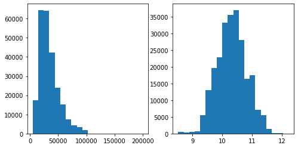

```python
data['Log1pSalary'] = np.log1p(data['SalaryNormalized']).astype('float32')

plt.figure(figsize=[8, 4])
plt.subplot(1, 2, 1)
plt.hist(data["SalaryNormalized"], bins=20);

plt.subplot(1, 2, 2)
plt.hist(data['Log1pSalary'], bins=20);
```

```python
# ошибка на хвосте будет приводить к оверфиту
# поэтому таргет часто трансформируют - например, логарифм
```

Our task is to predict one number, **Log1pSalary**.

To do so, our model can access a number of features:

- Free text: **`Title`** and **`FullDescription`**
- Categorical: **`Category`**, **`Company`**, **`LocationNormalized`**, **`ContractType`**, and **`ContractTime`**.

```python
text_columns = ["Title", "FullDescription"]
categorical_columns = ["Category", "Company", "LocationNormalized", "ContractType", "ContractTime"]
TARGET_COLUMN = "Log1pSalary"

data[categorical_columns] = data[categorical_columns].fillna('NaN')  # cast missing values to string "NaN"
data[text_columns] = data[text_columns].fillna('NaN')

data.sample(3)
```

|  | Id | Title | FullDescription | LocationRaw | LocationNormalized | ContractType | ContractTime | Company | Category | SalaryRaw | SalaryNormalized | SourceName | Log1pSalary |
| --- | --- | --- | --- | --- | --- | --- | --- | --- | --- | --- | --- | --- | --- |
| 163882 | 71227612 | Car Sales Advisor | Car Sales Advisor The Company A fantastic oppo... | Leicester | Leicester | NaN | permanent | ULO Ltd T/A Capital Strategy Associates | Logistics & Warehouse Jobs | 14000 to 30000 | 22000 | jobsite.co.uk | 9.998843 |
| 191354 | 71750165 | Property Lawyers Residential Conveyancing | Role Residential Property Lawyers Location Car... | Cardiff, Wales | Cardiff | NaN | permanent | BKM Recruitment | Legal Jobs | 18000 - 30000/annum | 24000 | cv-library.co.uk | 10.085851 |
| 221319 | 72380798 | Planner/Buyer | Buyer / PlannerLocation: Hemel HempsteadRole S... | Hertfordshire - Hemel Hempstead | Hemel Hempstead | full_time | permanent | CVbrowser | Retail Jobs | 42240 - 52800 | 47520 | cvbrowser.com | 10.768927 |

### Preprocessing text data

Just like last week, applying NLP to a problem begins from tokenization: splitting raw text into sequences of tokens (words, punctuation, etc).

**Your task** is to lowercase and tokenize all texts under `Title` and `FullDescription` columns. Store the tokenized data as a **space-separated** string of tokens for performance reasons.

It's okay to use nltk tokenizers. Assertions were designed for WordPunctTokenizer, slight deviations are okay.

```python
print("Raw text:")
print(data["FullDescription"][2::100000])
```

```
Raw text:
2         Mathematical Modeller / Simulation Analyst / O...
100002    A successful and high achieving specialist sch...
200002    Web Designer  HTML, CSS, JavaScript, Photoshop...
Name: FullDescription, dtype: object
```

```python
import nltk

tokenizer = nltk.tokenize.WordPunctTokenizer()

data[text_columns] = data[text_columns].applymap(lambda x: " ".join(tokenizer.tokenize(x.lower())))
```

Now we can assume that our text is a space-separated list of tokens:

```python
print("Tokenized:")
print(data["FullDescription"][2::100000])
assert data["FullDescription"][2][:50] == 'mathematical modeller / simulation analyst / opera'
assert data["Title"][54321] == 'international digital account manager ( german )'
```

```
Tokenized:
2         mathematical modeller / simulation analyst / o...
100002    a successful and high achieving specialist sch...
200002    web designer html , css , javascript , photosh...
Name: FullDescription, dtype: object
```

Not all words are equally useful. Some of them are typos or rare words that are only present a few times.

Let's count how many times is each word present in the data so that we can build a "white list" of known words.

```python
from collections import Counter
token_counts = Counter()
# Count how many times does each token occur in both "Title" and "FullDescription" in total

for col in text_columns:
    for line in data[col].values:
        token_counts.update(line.split(" "))
```

```python
print("Total unique tokens :", len(token_counts))
print('\n'.join(map(str, token_counts.most_common(n=5))))
print('...')
print('\n'.join(map(str, token_counts.most_common()[-3:])))

assert token_counts.most_common(1)[0][1] in  range(2600000, 2700000)
assert len(token_counts) in range(200000, 210000)
print('Correct!')
```

```
Total unique tokens : 202704
('and', 2657388)
('.', 2523216)
(',', 2318606)
('the', 2080994)
('to', 2019884)
...
('stephanietraveltraderecruitmnt', 1)
('ruabon', 1)
('lowehays', 1)
Correct!
```

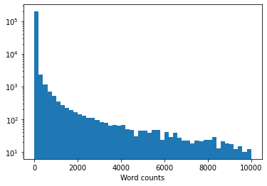

```python
# Let's see how many words are there for each count
plt.hist(list(token_counts.values()), range=[0, 10**4], bins=50, log=True)
plt.xlabel("Word counts");
```

```python
min_count = 10

# tokens from token_counts keys that had at least min_count occurrences throughout the dataset
tokens = sorted(t for t, c in token_counts.items() if c >= min_count)

# Add a special tokens for unknown and empty words
UNK, PAD = "UNK", "PAD"
tokens = [UNK, PAD] + tokens
```

```python
print("Vocabulary size:", len(tokens))
assert type(tokens) == list
assert len(tokens) in range(32000, 35000)
assert 'me' in tokens
assert UNK in tokens
print("Correct!")
```

```
Vocabulary size: 34158
Correct!
```

```python
token_to_id = {t: i for i, t in enumerate(tokens)}
```

```python
assert isinstance(token_to_id, dict)
assert len(token_to_id) == len(tokens)
for tok in tokens:
    assert tokens[token_to_id[tok]] == tok

print("Correct!")
```

```
Correct!
```

And finally, let's use the vocabulary you've built to map text lines into neural network-digestible matrices.

```python
UNK_IX, PAD_IX = map(token_to_id.get, [UNK, PAD])

def as_matrix(sequences, max_len=None):
    """ Convert a list of tokens into a matrix with padding """
    if isinstance(sequences[0], str):
        sequences = list(map(str.split, sequences))

    max_len = min(max(map(len, sequences)), max_len or float('inf'))

    matrix = np.full((len(sequences), max_len), np.int32(PAD_IX))
    for i,seq in enumerate(sequences):
        row_ix = [token_to_id.get(word, UNK_IX) for word in seq[:max_len]]
        matrix[i, :len(row_ix)] = row_ix

    return matrix
```

```python
print("Lines:")
print('\n'.join(data["Title"][::100000].values), end='\n\n')
print("Matrix:")
print(as_matrix(data["Title"][::100000]))
```

```
Lines:
engineering systems analyst
hr assistant
senior ec & i engineer

Matrix:
[[10807 30161  2166     1     1]
 [15020  2844     1     1     1]
 [27645 10201    16 15215 10804]]
```

Now let's encode the categirical data we have.

As usual, we shall use one-hot encoding for simplicity. Kudos if you implement more advanced encodings: tf-idf, pseudo-time-series, etc.

```python
from sklearn.feature_extraction import DictVectorizer

# we only consider top-1k most frequent companies to minimize memory usage
top_companies, top_counts = zip(*Counter(data['Company']).most_common(1000))
recognized_companies = set(top_companies)
data["Company"] = data["Company"].apply(lambda comp: comp if comp in recognized_companies else "Other")

categorical_vectorizer = DictVectorizer(dtype=np.float32, sparse=False)

categorical_vectorizer.fit(data[categorical_columns].apply(dict, axis=1))
```

```
DictVectorizer(dtype=<class 'numpy.float32'>, sparse=False)
```

### The deep learning part

Once we've learned to tokenize the data, let's design a machine learning experiment.

As before, we won't focus too much on validation, opting for a simple train-test split.

**To be completely rigorous,** we've comitted a small crime here: we used the whole data for tokenization and vocabulary building. A more strict way would be to do that part on training set only. You may want to do that and measure the magnitude of changes.

Заранее выделим отложенную валидационную часть. Данные будут разделены следующим образом:

- data_train - 0.8
- data_val - 0.1
- data_holdout - 0.1

```python
data_holdout = data.sample(frac=0.1)
```

```python
data_holdout.shape
```

```
(24477, 13)
```

```python
data.shape
```

```
(244768, 13)
```

```python
data_remaining = data.iloc[pd.Int64Index(set(data.index) - set(data_holdout.index))]
```

```python
from sklearn.model_selection import train_test_split

data_train, data_val = train_test_split(data_remaining, test_size=0.1, random_state=77)
data_train.index = range(len(data_train))
data_val.index = range(len(data_val))

print("Train size = ", len(data_train))
print("Test size = ", len(data_val))
```

```
Train size =  198261
Test size =  22030
```

```python
import torch

def to_tensors(batch, device):
    batch_tensors = dict()
    for key, arr in batch.items():
        if key in ["FullDescription", "Title"]:
            batch_tensors[key] = torch.tensor(arr, device=device, dtype=torch.int64)
        else:
            batch_tensors[key] = torch.tensor(arr, device=device)
    return batch_tensors

def make_batch(data, max_len=None, word_dropout=0, device=torch.device('cpu')):
    """
    Creates a keras-friendly dict from the batch data.
    :param word_dropout: replaces token index with UNK_IX with this probability
    :returns: a dict with {'title' : int64[batch, title_max_len]
    """
    batch = {}
    batch['Id'] = data['Id'].values
    batch["Title"] = as_matrix(data["Title"].values, max_len)
    batch["FullDescription"] = as_matrix(data["FullDescription"].values, max_len)
    batch['Categorical'] = categorical_vectorizer.transform(data[categorical_columns].apply(dict, axis=1))

    if word_dropout != 0:
        batch["FullDescription"] = apply_word_dropout(batch["FullDescription"], 1. - word_dropout)

    if TARGET_COLUMN in data.columns:
        batch[TARGET_COLUMN] = data[TARGET_COLUMN].values

    return to_tensors(batch, device)

def apply_word_dropout(matrix, keep_prop, replace_with=UNK_IX, pad_ix=PAD_IX,):
    dropout_mask = np.random.choice(2, np.shape(matrix), p=[keep_prop, 1 - keep_prop])
    dropout_mask &= matrix != pad_ix
    return np.choose(dropout_mask, [matrix, np.full_like(matrix, replace_with)])
```

```python
as_matrix(data['FullDescription'][0:3].values, max_len=30)
```

```
array([[10807, 30161,  2166,  9726, 29944, 26980,    82, 17043, 22209,
         6409, 16451, 18309, 15554,  9726,   158, 29944,  2189,  2572,
        18414, 12587, 10807, 30161,  2166, 22209,  6409, 24520, 28850,
        28606,  9083, 17231],
       [29514, 10804, 13463, 26980,    82, 31100,    82, 33070, 25162,
         8165, 18414, 12587, 30246, 10813, 31100, 16898, 22209, 13845,
        13463, 30412,  2920,   982, 32423, 21634, 17947,   169, 30746,
        26627,  2572, 15289],
       [19175, 20042,   197, 28207,  2166,   197, 21922,  2166,  3569,
          158, 14056, 32170, 31100,    82, 17043,     0, 22911,  7430,
          158, 24182, 19426,  2189,  8867, 30746, 21956, 22209,  6409,
        16451,  2142, 15661]], dtype=int32)
```

# Base model

#### Architecture

Our basic model consists of three branches:

- Title encoder
- Description encoder
- Categorical features encoder

We will then feed all 3 branches into one common network that predicts salary.

[figure not shown]

This clearly doesn't fit into keras' **Sequential** interface. To build such a network, one will have to use PyTorch.

```python
import torch
import torch.nn as nn
import torch.functional as F
```

```python
models_and_metrics = {}
```

```python
class SalaryPredictor(nn.Module):
    def __init__(self, n_tokens=len(tokens), n_cat_features=len(categorical_vectorizer.vocabulary_), hid_size=8):
        super().__init__()
        self.embedder = nn.Embedding(n_tokens, hid_size)
        self.title_encoder = nn.Sequential(
            nn.Conv1d(hid_size, hid_size, kernel_size=2),
            nn.Dropout(p=0.25),
            nn.ReLU(),
            nn.AdaptiveMaxPool1d(output_size=1)
        )
        self.description_encoder = nn.Sequential(
            nn.Conv1d(hid_size, hid_size, kernel_size=2),
            nn.Dropout(p=0.25),
            nn.ReLU(),
            nn.AdaptiveMaxPool1d(output_size=1)
        )
        self.categorical_encoder = nn.Sequential(
            nn.Linear(n_cat_features, hid_size * 2),
            nn.ReLU(),
            nn.Linear(hid_size * 2, hid_size * 2),
            nn.ReLU()
        )
        self.final_predictor = nn.Sequential(
            nn.Linear(hid_size * 4, hid_size),
            nn.ReLU(),
            nn.Linear(hid_size, 1)
        )


    def forward(self, batch):
        title_embeddings = self.embedder(batch['Title']).permute(0, 2, 1)
        title_features = self.title_encoder(title_embeddings).squeeze()

        description_embeddings = self.embedder(batch['FullDescription']).permute(0, 2, 1)
        description_features = self.description_encoder(description_embeddings).squeeze()

        categorical_features = self.categorical_encoder(batch['Categorical'])

        features = torch.cat(
            [title_features, description_features, categorical_features], dim=1)

        return self.final_predictor(features).squeeze()
```

```python
model_base = SalaryPredictor()
batch = make_batch(data_train[:100])
criterion = nn.MSELoss()

dummy_pred = model_base(batch)
dummy_loss = criterion(dummy_pred, batch[TARGET_COLUMN])
assert dummy_pred.shape == torch.Size([100])
assert len(np.unique(dummy_pred.detach().numpy())) > 20, "model returns suspiciously few unique outputs. Check your initialization"
assert dummy_loss.ndim == 0 and 0. <= dummy_loss <= 250., "make sure you minimize MSE"
```

#### Training and evaluation

As usual, we gonna feed our monster with random minibatches of data.

As we train, we want to monitor not only loss function, which is computed in log-space, but also the actual error measured in dollars.

```python
def iterate_minibatches(data, batch_size=256, shuffle=True, cycle=False, **kwargs):
    """ iterates minibatches of data in random order """
    while True:
        indices = np.arange(len(data))
        if shuffle:
            indices = np.random.permutation(indices)

        for start in range(0, len(indices), batch_size):
            batch = make_batch(data.iloc[indices[start : start + batch_size]], **kwargs)
            yield batch

        if not cycle: break
```

### Model training

We can now fit our model the usual minibatch way. The interesting part is that we train on an infinite stream of minibatches, produced by `iterate_minibatches` function.

```python
import tqdm
```

```python
def return_metrics(model, data, batch_size, name="", **kw):
    squared_error = abs_error = num_samples = 0.0
    model.eval()
    with torch.no_grad():
        for batch in iterate_minibatches(data, batch_size=batch_size, shuffle=False, **kw):
            batch_pred = model(batch)
            squared_error += torch.mean(torch.square(batch_pred - batch[TARGET_COLUMN]))
            abs_error += torch.mean(torch.abs(batch_pred - batch[TARGET_COLUMN]))
            num_samples += len(batch)
    mse = squared_error.detach().cpu().numpy() / num_samples
    mae = abs_error.detach().cpu().numpy() / num_samples
    return mse, mae
```

```
epoch: 0
```

```
epoch: 1
```

```
epoch: 2
```

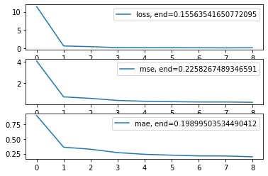

```python
BATCH_SIZE = 512
EPOCHS = 3
DEVICE = torch.device('cuda') if torch.cuda.is_available() else torch.device('cpu')

model_base = SalaryPredictor().to(DEVICE)
criterion = nn.MSELoss(reduction='mean')
optimizer = torch.optim.Adam(model_base.parameters(), lr=1e-3)

losses, mse, mae = [], [], []

for epoch in range(EPOCHS):
    print(f"epoch: {epoch}")
    for i, batch in tqdm.notebook.tqdm(enumerate(
            iterate_minibatches(
                    data_train,
                    batch_size=BATCH_SIZE,
                    device=DEVICE)),
                total=len(data_train) // BATCH_SIZE
        ):
        model_base.train()
        pred = model_base(batch)
        optimizer.zero_grad()
        loss = criterion(pred, batch[TARGET_COLUMN])
        loss.backward()
        optimizer.step()

        if i % 100 == 99:
            losses.append(loss.item())
            mse_item, mae_item = return_metrics(model_base, data_val, name='val', batch_size=BATCH_SIZE, device=DEVICE)
            mse.append(mse_item)
            mae.append(mae_item)

fig, ax = plt.subplots(nrows=3, ncols=1)

ax[0].plot(losses, label=f'loss, end={losses[-1]}')
ax[1].plot(mse, label=f'mse, end={mse[-1]}')
ax[2].plot(mae, label=f'mae, end={mae[-1]}')

for i in range(3):
    ax[i].legend(loc='upper right')

plt.show()
```

```python
models_and_metrics['base'] = {}
models_and_metrics['base']['losses'] = losses
models_and_metrics['base']['mse'] = mse
models_and_metrics['base']['mae'] = mae
```

# Часть 1

## Эксперимент 1

Добавим батч-норм

```python
class SalaryPredictor1(nn.Module):
    def __init__(self, n_tokens=len(tokens), n_cat_features=len(categorical_vectorizer.vocabulary_), hid_size=8):
        super().__init__()
        self.embedder = nn.Embedding(n_tokens, hid_size)
        self.title_encoder = nn.Sequential(
            nn.Conv1d(hid_size, hid_size, kernel_size=2),
            nn.BatchNorm1d(hid_size),
            nn.Dropout(p=0.25),
            nn.ReLU(),
            nn.AdaptiveMaxPool1d(output_size=1)
        )
        self.description_encoder = nn.Sequential(
            nn.Conv1d(hid_size, hid_size, kernel_size=2),
            nn.BatchNorm1d(hid_size),
            nn.Dropout(p=0.25),
            nn.ReLU(),
            nn.AdaptiveMaxPool1d(output_size=1)
        )
        self.categorical_encoder = nn.Sequential(
            nn.Linear(n_cat_features, hid_size * 2),
            nn.ReLU(),
            nn.Linear(hid_size * 2, hid_size * 2),
            nn.ReLU()
        )
        self.final_predictor = nn.Sequential(
            nn.Linear(hid_size * 4, hid_size),
            nn.ReLU(),
            nn.Linear(hid_size, 1)
        )


    def forward(self, batch):
        title_embeddings = self.embedder(batch['Title']).permute(0, 2, 1)
        title_features = self.title_encoder(title_embeddings).squeeze()

        description_embeddings = self.embedder(batch['FullDescription']).permute(0, 2, 1)
        description_features = self.description_encoder(description_embeddings).squeeze()

        categorical_features = self.categorical_encoder(batch['Categorical'])

        features = torch.cat(
            [title_features, description_features, categorical_features], dim=1)

        return self.final_predictor(features).squeeze()
```

```
epoch: 0
```

```
epoch: 1
```

```
epoch: 2
```

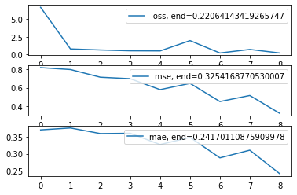

```python
BATCH_SIZE = 512
EPOCHS = 3
DEVICE = torch.device('cuda') if torch.cuda.is_available() else torch.device('cpu')

model1 = SalaryPredictor1().to(DEVICE)
criterion = nn.MSELoss(reduction='mean')
optimizer = torch.optim.Adam(model1.parameters(), lr=1e-3)

losses, mse, mae = [], [], []

for epoch in range(EPOCHS):
    print(f"epoch: {epoch}")
    for i, batch in tqdm.notebook.tqdm(enumerate(
            iterate_minibatches(
                    data_train,
                    batch_size=BATCH_SIZE,
                    device=DEVICE)),
                total=len(data_train) // BATCH_SIZE
        ):
        model1.train()
        pred = model1(batch)
        optimizer.zero_grad()
        loss = criterion(pred, batch[TARGET_COLUMN])
        loss.backward()
        optimizer.step()

        if i % 100 == 99:
            losses.append(loss.item())
            mse_item, mae_item = return_metrics(model1, data_val, name='val', batch_size=BATCH_SIZE, device=DEVICE)
            mse.append(mse_item)
            mae.append(mae_item)

fig, ax = plt.subplots(nrows=3, ncols=1)

ax[0].plot(losses, label=f'loss, end={losses[-1]}')
ax[1].plot(mse, label=f'mse, end={mse[-1]}')
ax[2].plot(mae, label=f'mae, end={mae[-1]}')

for i in range(3):
    ax[i].legend(loc='upper right')

plt.show()
```

```python
models_and_metrics['experiment1'] = {}
models_and_metrics['experiment1']['losses'] = losses
models_and_metrics['experiment1']['mse'] = mse
models_and_metrics['experiment1']['mae'] = mae
```

## Эксперимент 2

Заменим batch-norm на group-norm

```python
class SalaryPredictor2(nn.Module):
    def __init__(self, n_tokens=len(tokens), n_cat_features=len(categorical_vectorizer.vocabulary_), hid_size=8):
        super().__init__()
        self.embedder = nn.Embedding(n_tokens, hid_size)
        self.title_encoder = nn.Sequential(
            nn.Conv1d(hid_size, hid_size, kernel_size=2),
            nn.GroupNorm(hid_size, hid_size),
            nn.Dropout(p=0.25),
            nn.ReLU(),
            nn.AdaptiveMaxPool1d(output_size=1)
        )
        self.description_encoder = nn.Sequential(
            nn.Conv1d(hid_size, hid_size, kernel_size=2),
            nn.GroupNorm(hid_size, hid_size),
            nn.Dropout(p=0.25),
            nn.ReLU(),
            nn.AdaptiveMaxPool1d(output_size=1)
        )
        self.categorical_encoder = nn.Sequential(
            nn.Linear(n_cat_features, hid_size * 2),
            nn.ReLU(),
            nn.Linear(hid_size * 2, hid_size * 2),
            nn.ReLU()
        )
        self.final_predictor = nn.Sequential(
            nn.Linear(hid_size * 4, hid_size),
            nn.ReLU(),
            nn.Linear(hid_size, 1)
        )


    def forward(self, batch):
        title_embeddings = self.embedder(batch['Title']).permute(0, 2, 1)
        title_features = self.title_encoder(title_embeddings).squeeze()

        description_embeddings = self.embedder(batch['FullDescription']).permute(0, 2, 1)
        description_features = self.description_encoder(description_embeddings).squeeze()

        categorical_features = self.categorical_encoder(batch['Categorical'])

        features = torch.cat(
            [title_features, description_features, categorical_features], dim=1)

        return self.final_predictor(features).squeeze()
```

```
epoch: 0
```

```
epoch: 1
```

```
epoch: 2
```

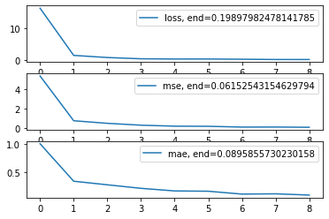

```python
BATCH_SIZE = 512
EPOCHS = 3
DEVICE = torch.device('cuda') if torch.cuda.is_available() else torch.device('cpu')

model2 = SalaryPredictor2().to(DEVICE)
criterion = nn.MSELoss(reduction='mean')
optimizer = torch.optim.Adam(model2.parameters(), lr=1e-3)

losses, mse, mae = [], [], []

for epoch in range(EPOCHS):
    print(f"epoch: {epoch}")
    for i, batch in tqdm.notebook.tqdm(enumerate(
            iterate_minibatches(
                    data_train,
                    batch_size=BATCH_SIZE,
                    device=DEVICE)),
                total=len(data_train) // BATCH_SIZE
        ):
        model2.train()
        pred = model2(batch)
        optimizer.zero_grad()
        loss = criterion(pred, batch[TARGET_COLUMN])
        loss.backward()
        optimizer.step()

        if i % 100 == 99:
            losses.append(loss.item())
            mse_item, mae_item = return_metrics(model2, data_val, name='val', batch_size=BATCH_SIZE, device=DEVICE)
            mse.append(mse_item)
            mae.append(mae_item)

fig, ax = plt.subplots(nrows=3, ncols=1)

ax[0].plot(losses, label=f'loss, end={losses[-1]}')
ax[1].plot(mse, label=f'mse, end={mse[-1]}')
ax[2].plot(mae, label=f'mae, end={mae[-1]}')

for i in range(3):
    ax[i].legend(loc='upper right')

plt.show()
```

```python
models_and_metrics['experiment2'] = {}
models_and_metrics['experiment2']['losses'] = losses
models_and_metrics['experiment2']['mse'] = mse
models_and_metrics['experiment2']['mae'] = mae
```

Модель получилась лучше Эксперимента 1

## Эксперимент 3

Параллельные конволюции

```python
class SalaryPredictor3(nn.Module):
    def __init__(self, n_tokens=len(tokens), n_cat_features=len(categorical_vectorizer.vocabulary_), hid_size=8):
        super().__init__()
        self.embedder = nn.Embedding(n_tokens, hid_size)
        self.title_encoder_head1 = nn.Sequential(
            nn.Conv1d(hid_size, hid_size, kernel_size=2)
        )
        self.title_encoder_head2 = nn.Sequential(
            nn.Conv1d(hid_size, hid_size, kernel_size=2)
        )
        self.title_encoder_tail = nn.Sequential(
            nn.BatchNorm1d(hid_size * 2),
            nn.Dropout(p=0.25),
            nn.ReLU(),
            nn.AdaptiveMaxPool1d(output_size=1),
            nn.ReLU()
        )
        self.description_encoder_head1 = nn.Sequential(
            nn.Conv1d(hid_size, hid_size, kernel_size=2)
        )
        self.description_encoder_head2 = nn.Sequential(
            nn.Conv1d(hid_size, hid_size, kernel_size=2)
        )
        self.description_encoder_tail = nn.Sequential(
            nn.BatchNorm1d(hid_size * 2),
            nn.Dropout(p=0.25),
            nn.ReLU(),
            nn.AdaptiveMaxPool1d(output_size=1),
            nn.ReLU()
        )
        self.categorical_encoder = nn.Sequential(
            nn.Linear(n_cat_features, hid_size * 2),
            nn.ReLU(),
            nn.Linear(hid_size * 2, hid_size * 2),
            nn.ReLU()
        )
        self.final_predictor = nn.Sequential(
            nn.Linear(hid_size * 6, hid_size),
            nn.ReLU(),
            nn.Linear(hid_size, 1),
            nn.ReLU()
        )


    def forward(self, batch):
        title_embeddings = self.embedder(batch['Title']).permute(0, 2, 1)

        title_features1 = self.title_encoder_head1(title_embeddings).squeeze()
        title_features2 = self.title_encoder_head2(title_embeddings).squeeze()

        title_features = torch.cat([title_features1, title_features2], dim=1)
        title_features = self.title_encoder_tail(title_features).squeeze()

        description_embeddings = self.embedder(batch['FullDescription']).permute(0, 2, 1)

        description_features1 = self.description_encoder_head1(description_embeddings).squeeze()
        description_features2 = self.description_encoder_head2(description_embeddings).squeeze()

        description_features = torch.cat([description_features1, description_features2], dim=1)
        description_features = self.description_encoder_tail(description_features).squeeze()

        categorical_features = self.categorical_encoder(batch['Categorical'])

        features = torch.cat(
            [
             title_features,
             description_features,
             categorical_features
             ], dim=1)
        return self.final_predictor(features).squeeze()
```

```
epoch: 0
```

```
epoch: 1
```

```
epoch: 2
```

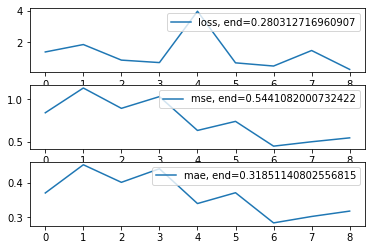

```python
BATCH_SIZE = 512
EPOCHS = 3
DEVICE = torch.device('cuda') if torch.cuda.is_available() else torch.device('cpu')

model3 = SalaryPredictor3().to(DEVICE)
criterion = nn.MSELoss(reduction='mean')
optimizer = torch.optim.Adam(model3.parameters(), lr=1e-3)

losses, mse, mae = [], [], []

for epoch in range(EPOCHS):
    print(f"epoch: {epoch}")
    for i, batch in tqdm.notebook.tqdm(enumerate(
            iterate_minibatches(
                    data_train,
                    batch_size=BATCH_SIZE,
                    device=DEVICE)),
                total=len(data_train) // BATCH_SIZE
        ):
        model3.train()
        pred = model3(batch)
        optimizer.zero_grad()
        loss = criterion(pred, batch[TARGET_COLUMN])
        loss.backward()
        optimizer.step()

        if i % 100 == 99:
            losses.append(loss.item())
            mse_item, mae_item = return_metrics(model3, data_val, name='val', batch_size=BATCH_SIZE, device=DEVICE)
            mse.append(mse_item)
            mae.append(mae_item)

fig, ax = plt.subplots(nrows=3, ncols=1)

ax[0].plot(losses, label=f'loss, end={losses[-1]}')
ax[1].plot(mse, label=f'mse, end={mse[-1]}')
ax[2].plot(mae, label=f'mae, end={mae[-1]}')

for i in range(3):
    ax[i].legend(loc='upper right')

plt.show()
```

```python
models_and_metrics['experiment3'] = {}
models_and_metrics['experiment3']['losses'] = losses
models_and_metrics['experiment3']['mse'] = mse
models_and_metrics['experiment3']['mae'] = mae
```

Модель получилась крайне нестабильной

## Эксперимент 4

Больше конволюционных слоёв

```python
class SalaryPredictor4(nn.Module):
    def __init__(self, n_tokens=len(tokens), n_cat_features=len(categorical_vectorizer.vocabulary_), hid_size=4):
        super().__init__()
        self.embedder = nn.Embedding(n_tokens, hid_size)
        self.title_encoder = nn.Sequential(
            nn.Conv1d(hid_size, hid_size, kernel_size=1),
            nn.Conv1d(hid_size, hid_size, kernel_size=2),
            nn.Conv1d(hid_size, hid_size, kernel_size=3),
            nn.GroupNorm(hid_size, hid_size),
            nn.Dropout(p=0.1),
            nn.ReLU(),
            nn.AdaptiveMaxPool1d(output_size=1)
        )
        self.description_encoder = nn.Sequential(
            nn.Conv1d(hid_size, hid_size, kernel_size=1),
            nn.Conv1d(hid_size, hid_size, kernel_size=2),
            nn.Conv1d(hid_size, hid_size, kernel_size=3),
            nn.GroupNorm(hid_size, hid_size),
            nn.Dropout(p=0.3),
            nn.ReLU(),
            nn.AdaptiveMaxPool1d(output_size=1)
        )
        self.categorical_encoder = nn.Sequential(
            nn.Linear(n_cat_features, hid_size * 2),
            nn.ReLU(),
            nn.Linear(hid_size * 2, hid_size * 2),
            nn.ReLU()
        )
        self.final_predictor = nn.Sequential(
            nn.Linear(hid_size * 4, hid_size),
            nn.ReLU(),
            nn.Linear(hid_size, 1)
        )


    def forward(self, batch):
        title_embeddings = self.embedder(batch['Title']).permute(0, 2, 1)
        title_features = self.title_encoder(title_embeddings).squeeze()

        description_embeddings = self.embedder(batch['FullDescription']).permute(0, 2, 1)
        description_features = self.description_encoder(description_embeddings).squeeze()

        categorical_features = self.categorical_encoder(batch['Categorical'])

        features = torch.cat(
            [title_features, description_features, categorical_features], dim=1)

        return self.final_predictor(features).squeeze()
```

```
epoch: 0
```

```
epoch: 1
```

```
epoch: 2
```

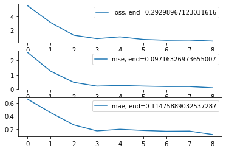

```python
BATCH_SIZE = 512
EPOCHS = 3
DEVICE = torch.device('cuda') if torch.cuda.is_available() else torch.device('cpu')

model4 = SalaryPredictor4().to(DEVICE)
criterion = nn.MSELoss(reduction='mean')
optimizer = torch.optim.Adam(model4.parameters(), lr=1e-3)

losses, mse, mae = [], [], []

for epoch in range(EPOCHS):
    print(f"epoch: {epoch}")
    for i, batch in tqdm.notebook.tqdm(enumerate(
            iterate_minibatches(
                    data_train,
                    batch_size=BATCH_SIZE,
                    device=DEVICE)),
                total=len(data_train) // BATCH_SIZE
        ):
        model4.train()
        pred = model4(batch)
        optimizer.zero_grad()
        loss = criterion(pred, batch[TARGET_COLUMN])
        loss.backward()
        optimizer.step()

        if i % 100 == 99:
            losses.append(loss.item())
            mse_item, mae_item = return_metrics(model4, data_val, name='val', batch_size=BATCH_SIZE, device=DEVICE)
            mse.append(mse_item)
            mae.append(mae_item)

fig, ax = plt.subplots(nrows=3, ncols=1)

ax[0].plot(losses, label=f'loss, end={losses[-1]}')
ax[1].plot(mse, label=f'mse, end={mse[-1]}')
ax[2].plot(mae, label=f'mae, end={mae[-1]}')

for i in range(3):
    ax[i].legend(loc='upper right')

plt.show()
```

```python
models_and_metrics['experiment4'] = {}
models_and_metrics['experiment4']['losses'] = losses
models_and_metrics['experiment4']['mse'] = mse
models_and_metrics['experiment4']['mae'] = mae
```

```python
models_and_min_metrics = {}

for model, metrics in models_and_metrics.items():
    print(model)
    models_and_min_metrics[model] = {}
    for metric_name, metric_values in metrics.items():
        print(f'min of {metric_name}: {min(metric_values):.2f}')
        models_and_min_metrics[model][metric_name] = min(metric_values)
    print()
```

```
base
min of losses: 0.14
min of mse: 0.23
min of mae: 0.20

experiment1
min of losses: 0.22
min of mse: 0.33
min of mae: 0.24

experiment2
min of losses: 0.20
min of mse: 0.06
min of mae: 0.09

experiment3
min of losses: 0.28
min of mse: 0.45
min of mae: 0.28

experiment4
min of losses: 0.29
min of mse: 0.10
min of mae: 0.11
```

Модель Base лучше всего уменьшила loss

По показателям лучше всего:

- mse: Experiment 2 и 4
- mae: Experiment 2 4

P.S.: от запуску к запуску то `model2`, то `model4` выбивается в лидерство.

## Эксперимент 5

Больше конволюционных слоёв + ранняя остановка

```
epoch: 0
```

```
epoch: 1
```

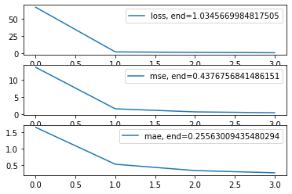

```python
early_stopping_patience = 5
early_stopping_tol = 0.1

BATCH_SIZE = 512
EPOCHS = 3
DEVICE = torch.device('cuda') if torch.cuda.is_available() else torch.device('cpu')

model5 = SalaryPredictor4().to(DEVICE)
criterion = nn.MSELoss(reduction='mean')
optimizer = torch.optim.Adam(model5.parameters(), lr=1e-3)

losses, mse, mae = [], [], []

patience_passed = 0
plateau_loss = 999

for epoch in range(EPOCHS):
    print(f"epoch: {epoch}")
    for i, batch in tqdm.notebook.tqdm(enumerate(
            iterate_minibatches(
                    data_train,
                    batch_size=BATCH_SIZE,
                    device=DEVICE)),
                total=len(data_train) // BATCH_SIZE
        ):
        model5.train()
        pred = model5(batch)
        optimizer.zero_grad()
        loss = criterion(pred, batch[TARGET_COLUMN])
        loss.backward()
        optimizer.step()

        if plateau_loss - early_stopping_tol <= loss.item() <= plateau_loss: # если между плато-толерантность и плато, то ждём
            patience_passed += 1
        elif loss.item() < plateau_loss - early_stopping_tol: # если сильно улучшили, то обнуляем ожидание
            plateau_loss = loss.item()
            patience_passed = 0

        if patience_passed > early_stopping_patience: # хватит ждать
            break

        if i % 100 == 99:
            losses.append(loss.item())
            mse_item, mae_item = return_metrics(model5, data_val, name='val', batch_size=BATCH_SIZE, device=DEVICE)
            mse.append(mse_item)
            mae.append(mae_item)

    # helps to break outer loop
    else:
        continue
    break

fig, ax = plt.subplots(nrows=3, ncols=1)

ax[0].plot(losses, label=f'loss, end={losses[-1]}')
ax[1].plot(mse, label=f'mse, end={mse[-1]}')
ax[2].plot(mae, label=f'mae, end={mae[-1]}')

for i in range(3):
    ax[i].legend(loc='upper right')

plt.show()
```

```python
models_and_metrics['experiment5'] = {}
models_and_metrics['experiment5']['losses'] = losses
models_and_metrics['experiment5']['mse'] = mse
models_and_metrics['experiment5']['mae'] = mae
```

```python
for model, metrics in models_and_metrics.items():
    print(model)
    for metric_name, metric_values in metrics.items():
        print(f'min of {metric_name}: {min(metric_values):.2f}')
    print()
```

```
base
min of losses: 0.14
min of mse: 0.23
min of mae: 0.20

experiment1
min of losses: 0.22
min of mse: 0.33
min of mae: 0.24

experiment2
min of losses: 0.20
min of mse: 0.06
min of mae: 0.09

experiment3
min of losses: 0.28
min of mse: 0.45
min of mae: 0.28

experiment4
min of losses: 0.29
min of mse: 0.10
min of mae: 0.11

experiment5
min of losses: 1.03
min of mse: 0.44
min of mae: 0.26
```

Модель получилась не самая лучшая, но достойная

## Сравнение моделей

```python
models = [model_base, model1, model2, model3, model4, model5]

for model in models:
    mse_item, mae_item = return_metrics(model, data_holdout, name='val', batch_size=BATCH_SIZE, device=DEVICE)
    print(f'mse: {mse_item}, mae: {mae_item}')
```

```
mse: 0.22346595128377278, mae: 0.19799272219340006
mse: 0.3332372029622396, mae: 0.24571491877237955
mse: 0.06107532978057861, mae: 0.08983024756113688
mse: 0.584878412882487, mae: 0.33177305857340494
mse: 0.10800210634867351, mae: 0.12365487416585287
mse: 0.421184508005778, mae: 0.25538385709126793
```

На отложенной валидационной выборке лучшей оказалась model2, с group norm

```python
model2
```

```
SalaryPredictor2(
  (embedder): Embedding(34158, 8)
  (title_encoder): Sequential(
    (0): Conv1d(8, 8, kernel_size=(2,), stride=(1,))
    (1): GroupNorm(8, 8, eps=1e-05, affine=True)
    (2): Dropout(p=0.25, inplace=False)
    (3): ReLU()
    (4): AdaptiveMaxPool1d(output_size=1)
  )
  (description_encoder): Sequential(
    (0): Conv1d(8, 8, kernel_size=(2,), stride=(1,))
    (1): GroupNorm(8, 8, eps=1e-05, affine=True)
    (2): Dropout(p=0.25, inplace=False)
    (3): ReLU()
    (4): AdaptiveMaxPool1d(output_size=1)
  )
  (categorical_encoder): Sequential(
    (0): Linear(in_features=3768, out_features=16, bias=True)
    (1): ReLU()
    (2): Linear(in_features=16, out_features=16, bias=True)
    (3): ReLU()
  )
  (final_predictor): Sequential(
    (0): Linear(in_features=32, out_features=8, bias=True)
    (1): ReLU()
    (2): Linear(in_features=8, out_features=1, bias=True)
  )
)
```

```python
data_holdout.shape
```

```
(24477, 13)
```

```python
models_and_answers = pd.DataFrame(columns=['Id', 'y_true'])
```

```python
for batch in iterate_minibatches(data_holdout, batch_size=BATCH_SIZE, shuffle=False):
    for id, true in zip(batch['Id'], batch['Log1pSalary']):
        models_and_answers = models_and_answers.append({
            'Id': id.item(),
            'y_true': true.item()
        }, ignore_index=True)
```

```python
for i, model in enumerate(models):
    model.eval()
    with torch.no_grad():
        preds = torch.Tensor([])
        for batch in iterate_minibatches(data_holdout, batch_size=BATCH_SIZE, shuffle=False):
            batch_pred = model(batch)
            preds = torch.cat([preds, batch_pred], 0)
        model_name = str(model)[0:str(model).index('(')]
        if i == len(models) - 1:
            model_name += '_earlyStop'
        models_and_answers[model_name] = pd.Series(preds)
```

```python
models_and_answers
```

|  | Id | y_true | SalaryPredictor | SalaryPredictor1 | SalaryPredictor2 | SalaryPredictor3 | SalaryPredictor4 | SalaryPredictor4_earlyStop |
| --- | --- | --- | --- | --- | --- | --- | --- | --- |
| 0 | 67151782.0 | 10.031221 | 9.039001 | 8.735724 | 9.787754 | 8.097836 | 9.397646 | 8.339832 |
| 1 | 67287073.0 | 10.389026 | 9.219996 | 9.097344 | 9.717443 | 8.497001 | 8.962393 | 8.267614 |
| 2 | 68834654.0 | 10.596660 | 9.681386 | 9.392022 | 10.140417 | 8.681621 | 9.688296 | 8.912350 |
| 3 | 64710042.0 | 9.933095 | 8.991764 | 8.353386 | 9.199016 | 7.806406 | 9.405335 | 9.885634 |
| 4 | 71420497.0 | 10.532123 | 9.276683 | 9.157598 | 10.133404 | 9.089185 | 9.890163 | 7.682638 |
| ... | ... | ... | ... | ... | ... | ... | ... | ... |
| 24472 | 70256433.0 | 10.389026 | 9.355554 | 9.029926 | 9.887851 | 8.583395 | 9.420391 | 8.538120 |
| 24473 | 68806802.0 | 10.477316 | 9.590663 | 9.453326 | 9.831005 | 8.857307 | 9.647855 | 8.001243 |
| 24474 | 65170566.0 | 9.615872 | 8.720833 | 8.419563 | 9.273678 | 8.228382 | 9.304945 | 8.241493 |
| 24475 | 70835658.0 | 9.566055 | 8.981587 | 9.174485 | 9.716569 | 8.391114 | 9.099445 | 8.453231 |
| 24476 | 71472933.0 | 10.463132 | 9.275554 | 9.494631 | 10.021428 | 8.297199 | 9.465113 | 8.782146 |

24477 rows × 8 columns

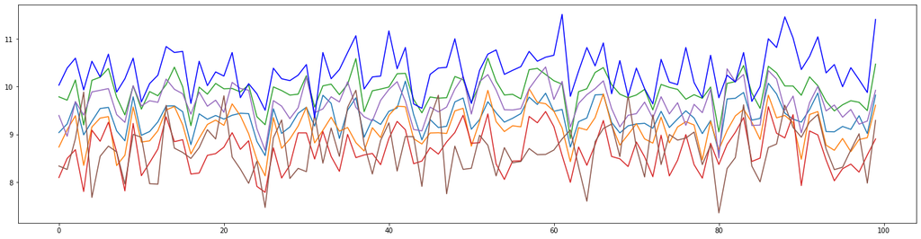

```python
figsize = (24, 6)
start, stop = 0, 100

models_and_answers.iloc[start:stop]['SalaryPredictor'].plot(figsize=figsize)
models_and_answers.iloc[start:stop]['SalaryPredictor1'].plot(figsize=figsize)
models_and_answers.iloc[start:stop]['SalaryPredictor2'].plot(figsize=figsize)
models_and_answers.iloc[start:stop]['SalaryPredictor3'].plot(figsize=figsize)
models_and_answers.iloc[start:stop]['SalaryPredictor4'].plot(figsize=figsize)
models_and_answers.iloc[start:stop]['SalaryPredictor4_earlyStop'].plot(figsize=figsize)
models_and_answers.iloc[start:stop]['y_true'].plot(figsize=figsize, style='b')
```

Видно, что около 40-го индекса и 60-го поведение похожее

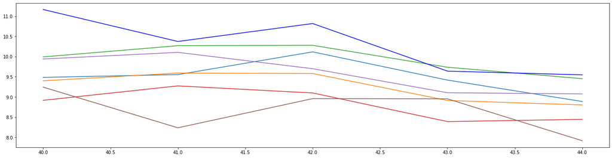

```python
figsize = (24, 6)
start, stop = 40, 45

models_and_answers.iloc[start:stop]['SalaryPredictor'].plot(figsize=figsize)
models_and_answers.iloc[start:stop]['SalaryPredictor1'].plot(figsize=figsize)
models_and_answers.iloc[start:stop]['SalaryPredictor2'].plot(figsize=figsize)
models_and_answers.iloc[start:stop]['SalaryPredictor3'].plot(figsize=figsize)
models_and_answers.iloc[start:stop]['SalaryPredictor4'].plot(figsize=figsize)
models_and_answers.iloc[start:stop]['SalaryPredictor4_earlyStop'].plot(figsize=figsize)
models_and_answers.iloc[start:stop]['y_true'].plot(figsize=figsize, style='b')
```

```python
data_holdout[data_holdout['Id'] == models_and_answers['Id'].iloc[43]]
```

|  | Id | Title | FullDescription | LocationRaw | LocationNormalized | ContractType | ContractTime | Company | Category | SalaryRaw | SalaryNormalized | SourceName | Log1pSalary |
| --- | --- | --- | --- | --- | --- | --- | --- | --- | --- | --- | --- | --- | --- |
| 23478 | 67444452 | welder / fabricator | to apply please forward cv / covering letter t... | London | London | full_time | NaN | Other | Manufacturing Jobs | 8.00 - 8.00 per hour | 15360 | Jobcentre Plus | 9.639587 |

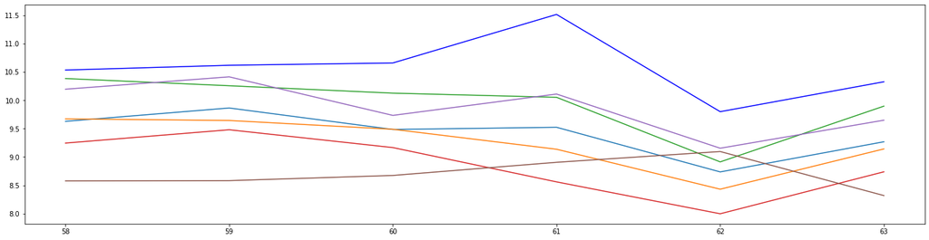

```python
figsize = (24, 6)
start, stop = 58, 64

models_and_answers.iloc[start:stop]['SalaryPredictor'].plot(figsize=figsize)
models_and_answers.iloc[start:stop]['SalaryPredictor1'].plot(figsize=figsize)
models_and_answers.iloc[start:stop]['SalaryPredictor2'].plot(figsize=figsize)
models_and_answers.iloc[start:stop]['SalaryPredictor3'].plot(figsize=figsize)
models_and_answers.iloc[start:stop]['SalaryPredictor4'].plot(figsize=figsize)
models_and_answers.iloc[start:stop]['SalaryPredictor4_earlyStop'].plot(figsize=figsize)
models_and_answers.iloc[start:stop]['y_true'].plot(figsize=figsize, style='b')
```

```python
data_holdout.loc[data_holdout['Id'].isin([models_and_answers['Id'].iloc[59],
                                        models_and_answers['Id'].iloc[60],
                                        models_and_answers['Id'].iloc[61],
                                        models_and_answers['Id'].iloc[62]])]
```

|  | Id | Title | FullDescription | LocationRaw | LocationNormalized | ContractType | ContractTime | Company | Category | SalaryRaw | SalaryNormalized | SourceName | Log1pSalary |
| --- | --- | --- | --- | --- | --- | --- | --- | --- | --- | --- | --- | --- | --- |
| 41058 | 68372619 | business intelligence analyst west yorkshire 2... | i have a requirement for a business intelligen... | West Yorkshire West Yorkshire England | West Yorkshire | NaN | NaN | Progressive Recruitment | IT Jobs | 150 -190 per day | 40800 | gojobsearch.co.uk | 10.616462 |
| 231884 | 72460171 | web analytics manager ( user experience intell... | web analytics manager ( user experience intell... | Hemel Hempstead | Hemel Hempstead | NaN | permanent | Other | IT Jobs | 35-50K + car allowance, bonus, bens. | 42500 | jobsite.co.uk | 10.657283 |
| 20629 | 67212158 | business development executive it solutions | specialist computer holdings ( sch ), is europ... | London, England | London | NaN | NaN | NaN | Sales Jobs | 99999.99 | 99999 | britishjobsonthe.net | 11.512925 |
| 149820 | 70763988 | medical advisor part time | a great opportunity for a qualified / register... | gu9, Surrey | Lower Hale | NaN | contract | Other | Healthcare & Nursing Jobs | 18000/annum | 18000 | cv-library.co.uk | 9.798182 |

Очень сложно предположить, с чем связано одинаковое поведение моделей. На первый взгляд все записи абсолютно рядовые и не предоставляют никаких подсказок для определения з/п. Можно заметить, что почти все модели одинаково (одинаково плохо) предсказывают з/п - чуть ниже настоящей платы.

# Часть 2

## Как работает Pooling слой

```python
pool = nn.AdaptiveMaxPool1d(output_size=1)
inpt = torch.Tensor([[1, 3, 4, 5, 4, 3, 2, 1, 5, 4, 6, 10]])
pool(inpt)
```

```
tensor([[10.]])
```

```python
pool = nn.AdaptiveMaxPool1d(output_size=2)
inpt = torch.Tensor([[1, 3, 4, 5, 4, 3, 2, 1, 5, 4, 6, 10]])
pool(inpt)
```

```
tensor([[ 5., 10.]])
```

```python
pool = nn.AdaptiveMaxPool1d(output_size=4)
inpt = torch.Tensor([[1, 3, 4, 5, 4, 3, 2, 1, 5, 4, 6, 10]])
pool(inpt)
```

```
tensor([[ 4.,  5.,  5., 10.]])
```

Pooling-слои делят вход на части, число которых указывается как `output_size`. После для каждой части определяется максимум - у нас же MaxPooling. Суть Adaptive в определении `kernel_size` и `stride` по формулам, исходя из значений `output_size` и `input_size`

## Эксперимент 6

Максимум по временной компоненте

```python
class SalaryPredictor6(nn.Module):
    def __init__(self, n_tokens=len(tokens), n_cat_features=len(categorical_vectorizer.vocabulary_), hid_size=4):
        super().__init__()
        self.embedder = nn.Embedding(n_tokens, hid_size)
        self.title_encoder = nn.Sequential(
            nn.Conv1d(hid_size, hid_size, kernel_size=1),
            nn.Conv1d(hid_size, hid_size, kernel_size=1),
            nn.Conv1d(hid_size, hid_size, kernel_size=1),
            nn.GroupNorm(hid_size, hid_size),
            nn.Dropout(p=0.1),
            nn.ReLU()
        )
        self.description_encoder = nn.Sequential(
            nn.Conv1d(hid_size, hid_size, kernel_size=1),
            nn.Conv1d(hid_size, hid_size, kernel_size=1),
            nn.Conv1d(hid_size, hid_size, kernel_size=1),
            nn.GroupNorm(hid_size, hid_size),
            nn.Dropout(p=0.3),
            nn.ReLU()
        )
        self.categorical_encoder = nn.Sequential(
            nn.Linear(n_cat_features, hid_size * 2),
            nn.ReLU(),
            nn.Linear(hid_size * 2, hid_size * 2),
            nn.ReLU()
        )
        self.final_predictor = nn.Sequential(
            nn.Linear(hid_size * 4, hid_size),
            nn.ReLU(),
            nn.Linear(hid_size, 1)
        )


    def forward(self, batch):
        title_embeddings = self.embedder(batch['Title']).permute(0, 2, 1)

        title_features = self.title_encoder(title_embeddings).max(dim=2)[0]

        description_embeddings = self.embedder(batch['FullDescription']).permute(0, 2, 1)
        description_features = self.description_encoder(description_embeddings).max(dim=2)[0]

        categorical_features = self.categorical_encoder(batch['Categorical'])

        features = torch.cat(
            [title_features, description_features, categorical_features], dim=1)

        return self.final_predictor(features).squeeze()
```

```
epoch: 0
```

```
epoch: 1
```

```
epoch: 2
```

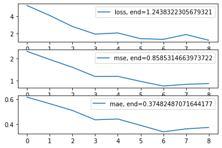

```python
BATCH_SIZE = 512
EPOCHS = 3
DEVICE = torch.device('cuda') if torch.cuda.is_available() else torch.device('cpu')

model6 = SalaryPredictor6().to(DEVICE)
criterion = nn.MSELoss(reduction='mean')
optimizer = torch.optim.Adam(model6.parameters(), lr=1e-3)

losses, mse, mae = [], [], []

for epoch in range(EPOCHS):
    print(f"epoch: {epoch}")
    for i, batch in tqdm.notebook.tqdm(enumerate(
            iterate_minibatches(
                    data_train,
                    batch_size=BATCH_SIZE,
                    device=DEVICE)),
                total=len(data_train) // BATCH_SIZE
        ):
        model6.train()
        pred = model6(batch)
        optimizer.zero_grad()
        loss = criterion(pred, batch[TARGET_COLUMN])
        loss.backward()
        optimizer.step()

        if i % 100 == 99:
            losses.append(loss.item())
            mse_item, mae_item = return_metrics(model6, data_val, name='val', batch_size=BATCH_SIZE, device=DEVICE)
            mse.append(mse_item)
            mae.append(mae_item)

fig, ax = plt.subplots(nrows=3, ncols=1)

ax[0].plot(losses, label=f'loss, end={losses[-1]}')
ax[1].plot(mse, label=f'mse, end={mse[-1]}')
ax[2].plot(mae, label=f'mae, end={mae[-1]}')

for i in range(3):
    ax[i].legend(loc='upper right')

plt.show()
```

```python
models_and_metrics['experiment6'] = {}
models_and_metrics['experiment6']['losses'] = losses
models_and_metrics['experiment6']['mse'] = mse
models_and_metrics['experiment6']['mae'] = mae
```

## Эксперимент 7

Среднее по временной шкале

```python
class SalaryPredictor7(nn.Module):
    def __init__(self, n_tokens=len(tokens), n_cat_features=len(categorical_vectorizer.vocabulary_), hid_size=4):
        super().__init__()
        self.embedder = nn.Embedding(n_tokens, hid_size)
        self.title_encoder = nn.Sequential(
            nn.Conv1d(hid_size, hid_size, kernel_size=1),
            nn.Conv1d(hid_size, hid_size, kernel_size=1),
            nn.Conv1d(hid_size, hid_size, kernel_size=1),
            nn.GroupNorm(hid_size, hid_size),
            nn.Dropout(p=0.1),
            nn.ReLU()
        )
        self.description_encoder = nn.Sequential(
            nn.Conv1d(hid_size, hid_size, kernel_size=1),
            nn.Conv1d(hid_size, hid_size, kernel_size=1),
            nn.Conv1d(hid_size, hid_size, kernel_size=1),
            nn.GroupNorm(hid_size, hid_size),
            nn.Dropout(p=0.3),
            nn.ReLU()
        )
        self.categorical_encoder = nn.Sequential(
            nn.Linear(n_cat_features, hid_size * 2),
            nn.ReLU(),
            nn.Linear(hid_size * 2, hid_size * 2),
            nn.ReLU()
        )
        self.final_predictor = nn.Sequential(
            nn.Linear(hid_size * 4, hid_size),
            nn.ReLU(),
            nn.Linear(hid_size, 1)
        )


    def mean(self, batch):
        with torch.no_grad():
            return batch.sum(axis=2) / (batch.sum(axis=1) > 0).sum(axis=1).view(-1,1).float()


    def forward(self, batch):
        title_embeddings = self.embedder(batch['Title']).permute(0, 2, 1)
        title_features = self.mean(self.title_encoder(title_embeddings))

        # title_features_2 = self.title_encoder(title_embeddings).mean(dim=2)

        description_embeddings = self.embedder(batch['FullDescription']).permute(0, 2, 1)
        description_features = self.mean(self.description_encoder(description_embeddings))

        # description_features_2 = self.description_encoder(description_embeddings).mean(dim=2)

        categorical_features = self.categorical_encoder(batch['Categorical'])

        features = torch.cat(
            [title_features, description_features, categorical_features], dim=1)

        return self.final_predictor(features).squeeze()
```

```
epoch: 0
```

```
epoch: 1
```

```
epoch: 2
```

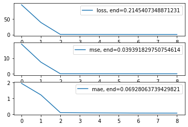

```python
BATCH_SIZE = 512
EPOCHS = 3
DEVICE = torch.device('cuda') if torch.cuda.is_available() else torch.device('cpu')

model7 = SalaryPredictor7().to(DEVICE)
criterion = nn.MSELoss(reduction='mean')
optimizer = torch.optim.Adam(model7.parameters(), lr=1e-3)

losses, mse, mae = [], [], []

for epoch in range(EPOCHS):
    print(f"epoch: {epoch}")
    for i, batch in tqdm.notebook.tqdm(enumerate(
            iterate_minibatches(
                    data_train,
                    batch_size=BATCH_SIZE,
                    device=DEVICE)),
                total=len(data_train) // BATCH_SIZE
        ):
        model7.train()
        pred = model7(batch)
        optimizer.zero_grad()
        loss = criterion(pred, batch[TARGET_COLUMN])
        loss.backward()
        optimizer.step()

        if i % 100 == 99:
            losses.append(loss.item())
            mse_item, mae_item = return_metrics(model7, data_val, name='val', batch_size=BATCH_SIZE, device=DEVICE)
            mse.append(mse_item)
            mae.append(mae_item)

fig, ax = plt.subplots(nrows=3, ncols=1)

ax[0].plot(losses, label=f'loss, end={losses[-1]}')
ax[1].plot(mse, label=f'mse, end={mse[-1]}')
ax[2].plot(mae, label=f'mae, end={mae[-1]}')

for i in range(3):
    ax[i].legend(loc='upper right')

plt.show()
```

```python
models_and_metrics['experiment7'] = {}
models_and_metrics['experiment7']['losses'] = losses
models_and_metrics['experiment7']['mse'] = mse
models_and_metrics['experiment7']['mae'] = mae
```

## Сравнение моделей

```python
models = [model_base, model1, model2, model3, model4, model5, model6, model7]

for model in models:
    mse_item, mae_item = return_metrics(model, data_holdout, name='val', batch_size=BATCH_SIZE, device=DEVICE)
    print(f'mse: {mse_item}, mae: {mae_item}')
```

```
mse: 0.22346595128377278, mae: 0.19799272219340006
mse: 0.3332372029622396, mae: 0.24571491877237955
mse: 0.06107532978057861, mae: 0.08983024756113688
mse: 0.584878412882487, mae: 0.33177305857340494
mse: 0.10800210634867351, mae: 0.12365487416585287
mse: 0.421184508005778, mae: 0.25538385709126793
mse: 0.8242058436075846, mae: 0.3701987584431966
mse: 0.03759344816207886, mae: 0.06786204973856608
```

Лучшая модель - среднее по временной компоненте

# Часть 3

В этой части в качестве базовой модели будем использовать модель из Эксперимента 4

## Загрузка эмбеддингов

```python
import gensim
```

```python
all_sentences = pd.concat([pd.Series(['UNK', 'PAD']), data['Title'], data['FullDescription']])
```

```python
processed_sentences = []

for sentence in all_sentences:
    add = gensim.utils.simple_preprocess(sentence)
    if len(add) != 0:
        processed_sentences.append(add)
```

```python
word_embedding = gensim.models.Word2Vec(size=4, window=5, min_count=20)  # size should be equal to hid_size of model
word_embedding.build_vocab(sentences=processed_sentences)
word_embedding.train(sentences=processed_sentences, total_examples=len(processed_sentences), epochs=5)
```

```
(227794404, 292904915)
```

```python
word_embedding.wv['quality']
```

```
array([1.4243412 , 0.02041429, 4.4233475 , 8.61602   ], dtype=float32)
```

```python
# vocab из генсима отличается от токенов, которые мы использовали ранее
# поэтому надо изменить методы создания батчей

len(word_embedding.wv.vocab)
```

```
22686
```

```python
vocab_to_id = {t: i for i, t in enumerate(word_embedding.wv.vocab.keys())}
```

```python
def as_matrix_gensim(sequences, max_len=None):
    """ Convert a list of tokens into a matrix with padding """
    if isinstance(sequences[0], str):
        sequences = list(map(str.split, sequences))

    max_len = min(max(map(len, sequences)), max_len or float('inf'))

    matrix = np.full((len(sequences), max_len), np.int32(PAD_IX))
    for i, seq in enumerate(sequences):
        row_ix = [vocab_to_id.get(word, UNK_IX) for word in seq[:max_len]]
        matrix[i, :len(row_ix)] = row_ix

    return matrix
```

```python
def make_batch_gensim(data, max_len=None, word_dropout=0, device=torch.device('cpu')):
    """
    Creates a keras-friendly dict from the batch data.
    :param word_dropout: replaces token index with UNK_IX with this probability
    :returns: a dict with {'title' : int64[batch, title_max_len]
    """
    batch = {}
    batch['Id'] = data['Id'].values
    batch["Title"] = as_matrix_gensim(data["Title"].values, max_len)
    batch["FullDescription"] = as_matrix_gensim(data["FullDescription"].values, max_len)
    batch['Categorical'] = categorical_vectorizer.transform(data[categorical_columns].apply(dict, axis=1))

    if word_dropout != 0:
        batch["FullDescription"] = apply_word_dropout(batch["FullDescription"], 1. - word_dropout)

    if TARGET_COLUMN in data.columns:
        batch[TARGET_COLUMN] = data[TARGET_COLUMN].values

    return to_tensors(batch, device)
```

```python
def iterate_minibatches_gensim(data, batch_size=256, shuffle=True, cycle=False, **kwargs):
    """ iterates minibatches of data in random order """
    while True:
        indices = np.arange(len(data))
        if shuffle:
            indices = np.random.permutation(indices)

        for start in range(0, len(indices), batch_size):
            batch = make_batch_gensim(data.iloc[indices[start : start + batch_size]], **kwargs)
            yield batch

        if not cycle: break
```

```python
def return_metrics_gensim(model, data, batch_size, name="", **kw):
    squared_error = abs_error = num_samples = 0.0
    model.eval()
    with torch.no_grad():
        for batch in iterate_minibatches_gensim(data, batch_size=batch_size, shuffle=False, **kw):
            batch_pred = model(batch)
            squared_error += torch.mean(torch.square(batch_pred - batch[TARGET_COLUMN]))
            abs_error += torch.mean(torch.abs(batch_pred - batch[TARGET_COLUMN]))
            num_samples += len(batch)
    mse = squared_error.detach().cpu().numpy() / num_samples
    mae = abs_error.detach().cpu().numpy() / num_samples
    return mse, mae
```

## Эксперимент 8

Замороженные веса

```python
class SalaryPredictorPretrainedFrozenWeights(nn.Module):
    def __init__(self, n_cat_features=len(categorical_vectorizer.vocabulary_), hid_size=4, em=word_embedding):
        super().__init__()
        self.embedder = nn.Embedding.from_pretrained(torch.FloatTensor(em.wv.vectors))
        self.embedder.requires_grad_ = False
        self.title_encoder = nn.Sequential(
            nn.Conv1d(hid_size, hid_size, kernel_size=1),
            nn.Conv1d(hid_size, hid_size, kernel_size=2),
            nn.Conv1d(hid_size, hid_size, kernel_size=3),
            nn.GroupNorm(hid_size, hid_size),
            nn.Dropout(p=0.1),
            nn.ReLU(),
            nn.AdaptiveMaxPool1d(output_size=1)
        )
        self.description_encoder = nn.Sequential(
            nn.Conv1d(hid_size, hid_size, kernel_size=1),
            nn.Conv1d(hid_size, hid_size, kernel_size=2),
            nn.Conv1d(hid_size, hid_size, kernel_size=3),
            nn.GroupNorm(hid_size, hid_size),
            nn.Dropout(p=0.3),
            nn.ReLU(),
            nn.AdaptiveMaxPool1d(output_size=1)
        )
        self.categorical_encoder = nn.Sequential(
            nn.Linear(n_cat_features, hid_size * 2),
            nn.ReLU(),
            nn.Linear(hid_size * 2, hid_size * 2),
            nn.ReLU()
        )
        self.final_predictor = nn.Sequential(
            nn.Linear(hid_size * 4, hid_size),
            nn.ReLU(),
            nn.Linear(hid_size, 1)
        )


    def forward(self, batch):
        title_embeddings = self.embedder(batch['Title']).permute(0, 2, 1)
        title_features = self.title_encoder(title_embeddings).squeeze()

        description_embeddings = self.embedder(batch['FullDescription']).permute(0, 2, 1)
        description_features = self.description_encoder(description_embeddings).squeeze()

        categorical_features = self.categorical_encoder(batch['Categorical'])

        features = torch.cat(
            [title_features, description_features, categorical_features], dim=1)

        return self.final_predictor(features).squeeze()
```

```
epoch: 0
```

```
epoch: 1
```

```
epoch: 2
```

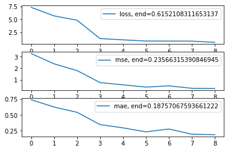

```python
BATCH_SIZE = 512
EPOCHS = 3
DEVICE = torch.device('cuda') if torch.cuda.is_available() else torch.device('cpu')

model8 = SalaryPredictorPretrainedFrozenWeights().to(DEVICE)
criterion = nn.MSELoss(reduction='mean')
optimizer = torch.optim.Adam(model8.parameters(), lr=1e-3)

losses, mse, mae = [], [], []

for epoch in range(EPOCHS):
    print(f"epoch: {epoch}")
    for i, batch in tqdm.notebook.tqdm(enumerate(
            iterate_minibatches_gensim(
                    data_train,
                    batch_size=BATCH_SIZE,
                    device=DEVICE)),
                total=len(data_train) // BATCH_SIZE
        ):
        model8.train()
        pred = model8(batch)
        optimizer.zero_grad()
        loss = criterion(pred, batch[TARGET_COLUMN])
        loss.backward()
        optimizer.step()

        if i % 100 == 99:
            losses.append(loss.item())
            mse_item, mae_item = return_metrics_gensim(model8, data_val, name='val', batch_size=BATCH_SIZE, device=DEVICE)
            mse.append(mse_item)
            mae.append(mae_item)

fig, ax = plt.subplots(nrows=3, ncols=1)

ax[0].plot(losses, label=f'loss, end={losses[-1]}')
ax[1].plot(mse, label=f'mse, end={mse[-1]}')
ax[2].plot(mae, label=f'mae, end={mae[-1]}')

for i in range(3):
    ax[i].legend(loc='upper right')

plt.show()
```

```python
models_and_metrics['experiment8'] = {}
models_and_metrics['experiment8']['losses'] = losses
models_and_metrics['experiment8']['mse'] = mse
models_and_metrics['experiment8']['mae'] = mae
```

## Эксперимент 9

Загруженные веса, но обучаемые

```python
class SalaryPredictorPretrainedUnfrozenWeights(nn.Module):
    def __init__(self, n_cat_features=len(categorical_vectorizer.vocabulary_), hid_size=4, em=word_embedding):
        super().__init__()
        self.embedder = nn.Embedding.from_pretrained(torch.FloatTensor(em.wv.vectors))
        self.embedder.requires_grad_ = True
        self.title_encoder = nn.Sequential(
            nn.Conv1d(hid_size, hid_size, kernel_size=1),
            nn.Conv1d(hid_size, hid_size, kernel_size=2),
            nn.Conv1d(hid_size, hid_size, kernel_size=3),
            nn.GroupNorm(hid_size, hid_size),
            nn.Dropout(p=0.1),
            nn.ReLU(),
            nn.AdaptiveMaxPool1d(output_size=1)
        )
        self.description_encoder = nn.Sequential(
            nn.Conv1d(hid_size, hid_size, kernel_size=1),
            nn.Conv1d(hid_size, hid_size, kernel_size=2),
            nn.Conv1d(hid_size, hid_size, kernel_size=3),
            nn.GroupNorm(hid_size, hid_size),
            nn.Dropout(p=0.3),
            nn.ReLU(),
            nn.AdaptiveMaxPool1d(output_size=1)
        )
        self.categorical_encoder = nn.Sequential(
            nn.Linear(n_cat_features, hid_size * 2),
            nn.ReLU(),
            nn.Linear(hid_size * 2, hid_size * 2),
            nn.ReLU()
        )
        self.final_predictor = nn.Sequential(
            nn.Linear(hid_size * 4, hid_size),
            nn.ReLU(),
            nn.Linear(hid_size, 1)
        )


    def forward(self, batch):
        title_embeddings = self.embedder(batch['Title']).permute(0, 2, 1)
        title_features = self.title_encoder(title_embeddings).squeeze()

        description_embeddings = self.embedder(batch['FullDescription']).permute(0, 2, 1)
        description_features = self.description_encoder(description_embeddings).squeeze()

        categorical_features = self.categorical_encoder(batch['Categorical'])

        features = torch.cat(
            [title_features, description_features, categorical_features], dim=1)

        return self.final_predictor(features).squeeze()
```

```
epoch: 0
```

```
epoch: 1
```

```
epoch: 2
```

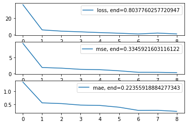

```python
BATCH_SIZE = 512
EPOCHS = 3
DEVICE = torch.device('cuda') if torch.cuda.is_available() else torch.device('cpu')

model9 = SalaryPredictorPretrainedUnfrozenWeights().to(DEVICE)
criterion = nn.MSELoss(reduction='mean')
optimizer = torch.optim.Adam(model9.parameters(), lr=1e-3)

losses, mse, mae = [], [], []

for epoch in range(EPOCHS):
    print(f"epoch: {epoch}")
    for i, batch in tqdm.notebook.tqdm(enumerate(
            iterate_minibatches_gensim(
                    data_train,
                    batch_size=BATCH_SIZE,
                    device=DEVICE)),
                total=len(data_train) // BATCH_SIZE
        ):
        model9.train()
        pred = model9(batch)
        optimizer.zero_grad()
        loss = criterion(pred, batch[TARGET_COLUMN])
        loss.backward()
        optimizer.step()

        if i % 100 == 99:
            losses.append(loss.item())
            mse_item, mae_item = return_metrics_gensim(model9, data_val, name='val', batch_size=BATCH_SIZE, device=DEVICE)
            mse.append(mse_item)
            mae.append(mae_item)

fig, ax = plt.subplots(nrows=3, ncols=1)

ax[0].plot(losses, label=f'loss, end={losses[-1]}')
ax[1].plot(mse, label=f'mse, end={mse[-1]}')
ax[2].plot(mae, label=f'mae, end={mae[-1]}')

for i in range(3):
    ax[i].legend(loc='upper right')

plt.show()
```

```python
models_and_metrics['experiment9'] = {}
models_and_metrics['experiment9']['losses'] = losses
models_and_metrics['experiment9']['mse'] = mse
models_and_metrics['experiment9']['mae'] = mae
```

## Эксперимент 10

Случайные веса, но данные из gensim

```python
class SalaryPredictorPretrainedRandom(nn.Module):
    def __init__(self, n_tokens=len(tokens), n_cat_features=len(categorical_vectorizer.vocabulary_), hid_size=4):
        super().__init__()
        self.embedder = nn.Embedding(n_tokens, hid_size)
        self.embedder.requires_grad_ = False
        self.title_encoder = nn.Sequential(
            nn.Conv1d(hid_size, hid_size, kernel_size=1),
            nn.Conv1d(hid_size, hid_size, kernel_size=2),
            nn.Conv1d(hid_size, hid_size, kernel_size=3),
            nn.GroupNorm(hid_size, hid_size),
            nn.Dropout(p=0.1),
            nn.ReLU(),
            nn.AdaptiveMaxPool1d(output_size=1)
        )
        self.description_encoder = nn.Sequential(
            nn.Conv1d(hid_size, hid_size, kernel_size=1),
            nn.Conv1d(hid_size, hid_size, kernel_size=2),
            nn.Conv1d(hid_size, hid_size, kernel_size=3),
            nn.GroupNorm(hid_size, hid_size),
            nn.Dropout(p=0.3),
            nn.ReLU(),
            nn.AdaptiveMaxPool1d(output_size=1)
        )
        self.categorical_encoder = nn.Sequential(
            nn.Linear(n_cat_features, hid_size * 2),
            nn.ReLU(),
            nn.Linear(hid_size * 2, hid_size * 2),
            nn.ReLU()
        )
        self.final_predictor = nn.Sequential(
            nn.Linear(hid_size * 4, hid_size),
            nn.ReLU(),
            nn.Linear(hid_size, 1)
        )


    def forward(self, batch):
        title_embeddings = self.embedder(batch['Title']).permute(0, 2, 1)
        title_features = self.title_encoder(title_embeddings).squeeze()

        description_embeddings = self.embedder(batch['FullDescription']).permute(0, 2, 1)
        description_features = self.description_encoder(description_embeddings).squeeze()

        categorical_features = self.categorical_encoder(batch['Categorical'])

        features = torch.cat(
            [title_features, description_features, categorical_features], dim=1)

        return self.final_predictor(features).squeeze()
```

```
epoch: 0
```

```
epoch: 1
```

```
epoch: 2
```

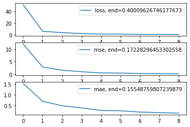

```python
BATCH_SIZE = 512
EPOCHS = 3
DEVICE = torch.device('cuda') if torch.cuda.is_available() else torch.device('cpu')

model10 = SalaryPredictorPretrainedRandom().to(DEVICE)
criterion = nn.MSELoss(reduction='mean')
optimizer = torch.optim.Adam(model10.parameters(), lr=1e-3)

losses, mse, mae = [], [], []

for epoch in range(EPOCHS):
    print(f"epoch: {epoch}")
    for i, batch in tqdm.notebook.tqdm(enumerate(
            iterate_minibatches_gensim(
                    data_train,
                    batch_size=BATCH_SIZE,
                    device=DEVICE)),
                total=len(data_train) // BATCH_SIZE
        ):
        model10.train()
        pred = model10(batch)
        optimizer.zero_grad()
        loss = criterion(pred, batch[TARGET_COLUMN])
        loss.backward()
        optimizer.step()

        if i % 100 == 99:
            losses.append(loss.item())
            mse_item, mae_item = return_metrics_gensim(model10, data_val, name='val', batch_size=BATCH_SIZE, device=DEVICE)
            mse.append(mse_item)
            mae.append(mae_item)

fig, ax = plt.subplots(nrows=3, ncols=1)

ax[0].plot(losses, label=f'loss, end={losses[-1]}')
ax[1].plot(mse, label=f'mse, end={mse[-1]}')
ax[2].plot(mae, label=f'mae, end={mae[-1]}')

for i in range(3):
    ax[i].legend(loc='upper right')

plt.show()
```

```python
models_and_metrics['experiment10'] = {}
models_and_metrics['experiment10']['losses'] = losses
models_and_metrics['experiment10']['mse'] = mse
models_and_metrics['experiment10']['mae'] = mae
```

## Сравнение моделей

```python
models = [model_base, model1, model2, model3, model4, model5, model6, model7, model8, model9, model10]

for model in models[0:8]:
    mse_item, mae_item = return_metrics(model, data_holdout, name='val', batch_size=BATCH_SIZE, device=DEVICE)
    print(f'mse: {mse_item}, mae: {mae_item}')

print('Gensim models:')
for model in models[8:]:
    mse_item, mae_item = return_metrics_gensim(model, data_holdout, name='val', batch_size=BATCH_SIZE, device=DEVICE)
    print(f'mse: {mse_item}, mae: {mae_item}')
```

```
mse: 0.22346595128377278, mae: 0.19799272219340006
mse: 0.3332372029622396, mae: 0.24571491877237955
mse: 0.06107532978057861, mae: 0.08983024756113688
mse: 0.584878412882487, mae: 0.33177305857340494
mse: 0.10800210634867351, mae: 0.12365487416585287
mse: 0.421184508005778, mae: 0.25538385709126793
mse: 0.8242058436075846, mae: 0.3701987584431966
mse: 0.03759344816207886, mae: 0.06786204973856608
Gensim models:
mse: 0.24022164344787597, mae: 0.1928995927174886
mse: 0.34279073079427086, mae: 0.2311941146850586
mse: 0.20923145612080893, mae: 0.17890160878499348
```

Выводы:

- случайные веса дали лучший результат
- потом идут замороженные веса
- модели, использующие временную компоненту (Часть 2) всё равно немного лучше

## Эксперимент 11

Разные эмбеддинги для Заголовка и Описания.

Будем использовать FastText для Заголовка и Word2Vec - для описания

```python
title_embedding = gensim.models.FastText(size=4, window=5, min_count=20)  # size should be equal to hid_size of model
title_embedding.build_vocab(sentences=processed_sentences)
title_embedding.train(sentences=processed_sentences, total_examples=len(processed_sentences), epochs=5)

description_embedding = gensim.models.Word2Vec(size=4, window=5, min_count=20)  # size should be equal to hid_size of model
description_embedding.build_vocab(sentences=processed_sentences)
description_embedding.train(sentences=processed_sentences, total_examples=len(processed_sentences), epochs=5)
```

```
(227795250, 292904915)
```

В качестве базы будем использовать замороженные веса (без возможности обучения)

```python
class SalaryPredictorPretrainedDifferentEmbeddings(nn.Module):
    def __init__(self, n_cat_features=len(categorical_vectorizer.vocabulary_), hid_size=4, title_em=title_embedding, desc_em=description_embedding):
        super().__init__()
        self.title_embedder = nn.Embedding.from_pretrained(torch.FloatTensor(title_em.wv.vectors))
        self.title_embedder.requires_grad_ = False

        self.description_embedder = nn.Embedding.from_pretrained(torch.FloatTensor(desc_em.wv.vectors))
        self.description_embedder.requires_grad_ = False

        self.title_encoder = nn.Sequential(
            nn.Conv1d(hid_size, hid_size, kernel_size=1),
            nn.Conv1d(hid_size, hid_size, kernel_size=2),
            nn.Conv1d(hid_size, hid_size, kernel_size=3),
            nn.GroupNorm(hid_size, hid_size),
            nn.Dropout(p=0.1),
            nn.ReLU(),
            nn.AdaptiveMaxPool1d(output_size=1)
        )
        self.description_encoder = nn.Sequential(
            nn.Conv1d(hid_size, hid_size, kernel_size=1),
            nn.Conv1d(hid_size, hid_size, kernel_size=2),
            nn.Conv1d(hid_size, hid_size, kernel_size=3),
            nn.GroupNorm(hid_size, hid_size),
            nn.Dropout(p=0.3),
            nn.ReLU(),
            nn.AdaptiveMaxPool1d(output_size=1)
        )
        self.categorical_encoder = nn.Sequential(
            nn.Linear(n_cat_features, hid_size * 2),
            nn.ReLU(),
            nn.Linear(hid_size * 2, hid_size * 2),
            nn.ReLU()
        )
        self.final_predictor = nn.Sequential(
            nn.Linear(hid_size * 4, hid_size),
            nn.ReLU(),
            nn.Linear(hid_size, 1)
        )


    def forward(self, batch):
        title_embeddings = self.title_embedder(batch['Title']).permute(0, 2, 1)
        title_features = self.title_encoder(title_embeddings).squeeze()

        description_embeddings = self.description_embedder(batch['FullDescription']).permute(0, 2, 1)
        description_features = self.description_encoder(description_embeddings).squeeze()

        categorical_features = self.categorical_encoder(batch['Categorical'])

        features = torch.cat(
            [title_features, description_features, categorical_features], dim=1)

        return self.final_predictor(features).squeeze()
```

```
epoch: 0
```

```
epoch: 1
```

```
epoch: 2
```

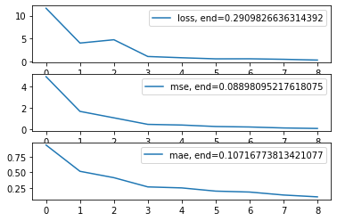

```python
BATCH_SIZE = 512
EPOCHS = 3
DEVICE = torch.device('cuda') if torch.cuda.is_available() else torch.device('cpu')

model11 = SalaryPredictorPretrainedDifferentEmbeddings().to(DEVICE)
criterion = nn.MSELoss(reduction='mean')
optimizer = torch.optim.Adam(model11.parameters(), lr=1e-3)

losses, mse, mae = [], [], []

for epoch in range(EPOCHS):
    print(f"epoch: {epoch}")
    for i, batch in tqdm.notebook.tqdm(enumerate(
            iterate_minibatches_gensim(
                    data_train,
                    batch_size=BATCH_SIZE,
                    device=DEVICE)),
                total=len(data_train) // BATCH_SIZE
        ):
        model11.train()
        pred = model11(batch)
        optimizer.zero_grad()
        loss = criterion(pred, batch[TARGET_COLUMN])
        loss.backward()
        optimizer.step()

        if i % 100 == 99:
            losses.append(loss.item())
            mse_item, mae_item = return_metrics_gensim(model11, data_val, name='val', batch_size=BATCH_SIZE, device=DEVICE)
            mse.append(mse_item)
            mae.append(mae_item)

fig, ax = plt.subplots(nrows=3, ncols=1)

ax[0].plot(losses, label=f'loss, end={losses[-1]}')
ax[1].plot(mse, label=f'mse, end={mse[-1]}')
ax[2].plot(mae, label=f'mae, end={mae[-1]}')

for i in range(3):
    ax[i].legend(loc='upper right')

plt.show()
```

```python
models_and_metrics['experiment11'] = {}
models_and_metrics['experiment11']['losses'] = losses
models_and_metrics['experiment11']['mse'] = mse
models_and_metrics['experiment11']['mae'] = mae
```

## Сравнение моделей

```python
models = [model_base, model1, model2, model3, model4, model5, model6, model7, model8, model9, model10, model11]

for model in models[0:8]:
    mse_item, mae_item = return_metrics(model, data_holdout, name='val', batch_size=BATCH_SIZE, device=DEVICE)
    print(f'mse: {mse_item}, mae: {mae_item}')

print('Gensim models:')
for model in models[8:]:
    mse_item, mae_item = return_metrics_gensim(model, data_holdout, name='val', batch_size=BATCH_SIZE, device=DEVICE)
    print(f'mse: {mse_item}, mae: {mae_item}')
```

```
mse: 0.22346595128377278, mae: 0.19799272219340006
mse: 0.3332372029622396, mae: 0.24571491877237955
mse: 0.06107532978057861, mae: 0.08983024756113688
mse: 0.584878412882487, mae: 0.33177305857340494
mse: 0.10800210634867351, mae: 0.12365487416585287
mse: 0.421184508005778, mae: 0.25538385709126793
mse: 0.8242058436075846, mae: 0.3701987584431966
mse: 0.03759344816207886, mae: 0.06786204973856608
Gensim models:
mse: 0.24022164344787597, mae: 0.1928995927174886
mse: 0.34279073079427086, mae: 0.2311941146850586
mse: 0.20923145612080893, mae: 0.17890160878499348
mse: 0.07848374843597412, mae: 0.10131595929463705
```

# Часть 4

## Подготовка

Механизмы внимания требуют предложения фиксированной длины. Нужно модифицировать получение данных. Ограничим длину предложений 30 словами - этот параметр настраиваемый и 30 слов дали оптимальный результат

```python
def as_matrix_fixed(sequences, max_len):
    """ Convert a list of tokens into a matrix with padding """
    if isinstance(sequences[0], str):
        sequences = list(map(str.split, sequences))

    matrix = np.full((len(sequences), max_len), np.int32(PAD_IX))
    for i,seq in enumerate(sequences):
        row_ix = [token_to_id.get(word, UNK_IX) for word in seq[:max_len]]
        matrix[i, :len(row_ix)] = row_ix

    return matrix
```

```python
def make_batch_fixed(data, max_len, word_dropout=0, device=torch.device('cpu')):
    """
    Creates a keras-friendly dict from the batch data.
    :param word_dropout: replaces token index with UNK_IX with this probability
    :returns: a dict with {'title' : int64[batch, title_max_len]
    """
    batch = {}
    batch['Id'] = data['Id'].values
    batch["Title"] = as_matrix_fixed(data["Title"].values, max_len)
    batch["FullDescription"] = as_matrix_fixed(data["FullDescription"].values, max_len)
    batch['Categorical'] = categorical_vectorizer.transform(data[categorical_columns].apply(dict, axis=1))

    if word_dropout != 0:
        batch["FullDescription"] = apply_word_dropout(batch["FullDescription"], 1. - word_dropout)

    if TARGET_COLUMN in data.columns:
        batch[TARGET_COLUMN] = data[TARGET_COLUMN].values

    return to_tensors(batch, device)
```

```python
def iterate_minibatches_fixed(data, batch_size=256, max_len=30, shuffle=True, cycle=False, **kwargs):
    """ iterates minibatches of data in random order """
    while True:
        indices = np.arange(len(data))
        if shuffle:
            indices = np.random.permutation(indices)

        for start in range(0, len(indices), batch_size):
            batch = make_batch_fixed(data.iloc[indices[start : start + batch_size]], max_len=max_len, **kwargs)
            yield batch

        if not cycle: break
```

```python
def return_metrics_fixed(model, data, batch_size, max_len=30, name="", **kw):
    squared_error = abs_error = num_samples = 0.0
    model.eval()
    with torch.no_grad():
        for batch in iterate_minibatches_fixed(data, batch_size=batch_size, max_len=max_len, shuffle=False, **kw):
            batch_pred = model(batch)
            squared_error += torch.mean(torch.square(batch_pred - batch[TARGET_COLUMN]))
            abs_error += torch.mean(torch.abs(batch_pred - batch[TARGET_COLUMN]))
            num_samples += len(batch)
    mse = squared_error.detach().cpu().numpy() / num_samples
    mae = abs_error.detach().cpu().numpy() / num_samples
    return mse, mae
```

## Эксперимент 12

LSTM

```python
class SalaryPredictorRecurrentLSTM(nn.Module):
    def __init__(self, n_tokens=len(tokens), n_cat_features=len(categorical_vectorizer.vocabulary_), hid_size=4, max_len=30):
        super().__init__()
        self.embedder = nn.Embedding(n_tokens, hid_size)
        self.lstm = nn.LSTM(max_len, hid_size, 2)
        self.title_encoder = nn.Sequential(
            nn.GroupNorm(hid_size, hid_size),
            nn.Dropout(p=0.1),
            nn.ReLU(),
            nn.AdaptiveMaxPool1d(output_size=1)
        )
        self.description_encoder = nn.Sequential(
            nn.GroupNorm(hid_size, hid_size),
            nn.Dropout(p=0.3),
            nn.ReLU(),
            nn.AdaptiveMaxPool1d(output_size=1)
        )
        self.categorical_encoder = nn.Sequential(
            nn.Linear(n_cat_features, hid_size * 2),
            nn.ReLU(),
            nn.Linear(hid_size * 2, hid_size * 2),
            nn.ReLU()
        )
        self.final_predictor = nn.Sequential(
            nn.Linear(hid_size * 4, hid_size),
            nn.ReLU(),
            nn.Linear(hid_size, 1)
        )


    def forward(self, batch):
        title_embeddings = self.embedder(batch['Title']).permute(0, 2, 1)
        title_features_lstm, (h_n, c_n) = self.lstm(title_embeddings)
        title_features = self.title_encoder(title_features_lstm).squeeze()

        description_embeddings = self.embedder(batch['FullDescription']).permute(0, 2, 1)
        description_features_lstm, (h_n, c_n) = self.lstm(description_embeddings)
        description_features = self.description_encoder(description_embeddings).squeeze()

        categorical_features = self.categorical_encoder(batch['Categorical'])

        features = torch.cat(
            [title_features, description_features, categorical_features], dim=1)

        return self.final_predictor(features).squeeze()
```

```
epoch: 0
```

```
epoch: 1
```

```
epoch: 2
```

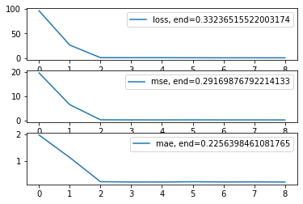

```python
BATCH_SIZE = 512
EPOCHS = 3
DEVICE = torch.device('cuda') if torch.cuda.is_available() else torch.device('cpu')

MAX_INPUT_LEN = 30

model12 = SalaryPredictorRecurrentLSTM(max_len=MAX_INPUT_LEN).to(DEVICE)
criterion = nn.MSELoss(reduction='mean')
optimizer = torch.optim.Adam(model12.parameters(), lr=1e-3)

losses, mse, mae = [], [], []

for epoch in range(EPOCHS):
    print(f"epoch: {epoch}")
    for i, batch in tqdm.notebook.tqdm(enumerate(
            iterate_minibatches_fixed(
                    data_train,
                    batch_size=BATCH_SIZE,
                    max_len=MAX_INPUT_LEN,
                    device=DEVICE)),
                total=len(data_train) // BATCH_SIZE
        ):
        model12.train()
        pred = model12(batch)
        optimizer.zero_grad()
        loss = criterion(pred, batch[TARGET_COLUMN])
        loss.backward()
        optimizer.step()

        if i % 100 == 99:
            losses.append(loss.item())
            mse_item, mae_item = return_metrics_fixed(model12, data_val, name='val', batch_size=BATCH_SIZE, max_len=MAX_INPUT_LEN, device=DEVICE)
            mse.append(mse_item)
            mae.append(mae_item)

fig, ax = plt.subplots(nrows=3, ncols=1)

ax[0].plot(losses, label=f'loss, end={losses[-1]}')
ax[1].plot(mse, label=f'mse, end={mse[-1]}')
ax[2].plot(mae, label=f'mae, end={mae[-1]}')

for i in range(3):
    ax[i].legend(loc='upper right')

plt.show()
```

```python
models_and_metrics['experiment12'] = {}
models_and_metrics['experiment12']['losses'] = losses
models_and_metrics['experiment12']['mse'] = mse
models_and_metrics['experiment12']['mae'] = mae
```

## Эксперимент 13

GRU

```python
class SalaryPredictorRecurrentGRU(nn.Module):
    def __init__(self, n_tokens=len(tokens), n_cat_features=len(categorical_vectorizer.vocabulary_), hid_size=4, max_len=30):
        super().__init__()
        self.embedder = nn.Embedding(n_tokens, hid_size)
        self.gru = nn.GRU(max_len, hid_size, 2)
        self.title_encoder = nn.Sequential(
            nn.GroupNorm(hid_size, hid_size),
            nn.Dropout(p=0.1),
            nn.ReLU(),
            nn.AdaptiveMaxPool1d(output_size=1)
        )
        self.description_encoder = nn.Sequential(
            nn.GroupNorm(hid_size, hid_size),
            nn.Dropout(p=0.3),
            nn.ReLU(),
            nn.AdaptiveMaxPool1d(output_size=1)
        )
        self.categorical_encoder = nn.Sequential(
            nn.Linear(n_cat_features, hid_size * 2),
            nn.ReLU(),
            nn.Linear(hid_size * 2, hid_size * 2),
            nn.ReLU()
        )
        self.final_predictor = nn.Sequential(
            nn.Linear(hid_size * 4, hid_size),
            nn.ReLU(),
            nn.Linear(hid_size, 1)
        )


    def forward(self, batch):
        title_embeddings = self.embedder(batch['Title']).permute(0, 2, 1)
        title_features_gru, (h_n, c_n) = self.gru(title_embeddings)
        title_features = self.title_encoder(title_features_gru).squeeze()

        description_embeddings = self.embedder(batch['FullDescription']).permute(0, 2, 1)
        description_features_gru, (h_n, c_n) = self.gru(description_embeddings)
        description_features = self.description_encoder(description_features_gru).squeeze()

        categorical_features = self.categorical_encoder(batch['Categorical'])

        features = torch.cat(
            [title_features, description_features, categorical_features], dim=1)

        return self.final_predictor(features).squeeze()
```

```
epoch: 0
```

```
epoch: 1
```

```
epoch: 2
```

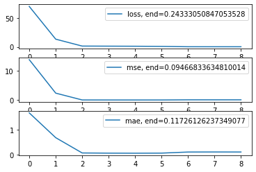

```python
BATCH_SIZE = 512
EPOCHS = 3
DEVICE = torch.device('cuda') if torch.cuda.is_available() else torch.device('cpu')

MAX_INPUT_LEN = 30

model13 = SalaryPredictorRecurrentGRU(max_len=MAX_INPUT_LEN).to(DEVICE)
criterion = nn.MSELoss(reduction='mean')
optimizer = torch.optim.Adam(model13.parameters(), lr=1e-3)

losses, mse, mae = [], [], []

for epoch in range(EPOCHS):
    print(f"epoch: {epoch}")
    for i, batch in tqdm.notebook.tqdm(enumerate(
            iterate_minibatches_fixed(
                    data_train,
                    batch_size=BATCH_SIZE,
                    max_len=MAX_INPUT_LEN,
                    device=DEVICE)),
                total=len(data_train) // BATCH_SIZE
        ):
        model13.train()
        pred = model13(batch)
        optimizer.zero_grad()
        loss = criterion(pred, batch[TARGET_COLUMN])
        loss.backward()
        optimizer.step()

        if i % 100 == 99:
            losses.append(loss.item())
            mse_item, mae_item = return_metrics_fixed(model13, data_val, name='val', batch_size=BATCH_SIZE, max_len=MAX_INPUT_LEN, device=DEVICE)
            mse.append(mse_item)
            mae.append(mae_item)

fig, ax = plt.subplots(nrows=3, ncols=1)

ax[0].plot(losses, label=f'loss, end={losses[-1]}')
ax[1].plot(mse, label=f'mse, end={mse[-1]}')
ax[2].plot(mae, label=f'mae, end={mae[-1]}')

for i in range(3):
    ax[i].legend(loc='upper right')

plt.show()
```

```python
models_and_metrics['experiment13'] = {}
models_and_metrics['experiment13']['losses'] = losses
models_and_metrics['experiment13']['mse'] = mse
models_and_metrics['experiment13']['mae'] = mae
```

## Эксперимент 14

BiGRU

```python
class SalaryPredictorRecurrentBiGRU(nn.Module):
    def __init__(self, n_tokens=len(tokens), n_cat_features=len(categorical_vectorizer.vocabulary_), hid_size=4, max_len=30):
        super().__init__()
        self.embedder = nn.Embedding(n_tokens, hid_size)
        self.gru = nn.GRU(max_len, hid_size, 2)
        self.reverse = nn.GRU(max_len, hid_size, 2)
        self.title_encoder = nn.Sequential(
            nn.GroupNorm(hid_size, hid_size),
            nn.Dropout(p=0.1),
            nn.ReLU(),
            nn.AdaptiveMaxPool1d(output_size=1)
        )
        self.description_encoder = nn.Sequential(
            nn.GroupNorm(hid_size, hid_size),
            nn.Dropout(p=0.3),
            nn.ReLU(),
            nn.AdaptiveMaxPool1d(output_size=1)
        )
        self.categorical_encoder = nn.Sequential(
            nn.Linear(n_cat_features, hid_size * 2),
            nn.ReLU(),
            nn.Linear(hid_size * 2, hid_size * 2),
            nn.ReLU()
        )
        self.final_predictor = nn.Sequential(
            nn.Linear(hid_size * 4, hid_size),
            nn.ReLU(),
            nn.Linear(hid_size, 1)
        )


    def forward(self, batch):
        title_embeddings = self.embedder(batch['Title']).permute(0, 2, 1)

        title_features_gru = self.gru(title_embeddings)[0]
        title_features_reverse_gru = torch.flip(self.gru(title_embeddings)[0], [2])
        title_features_concat = torch.concat([title_features_gru, title_features_reverse_gru], dim=2)
        title_features = self.title_encoder(title_features_concat).squeeze()

        description_embeddings = self.embedder(batch['FullDescription']).permute(0, 2, 1)
        description_features_gru = self.gru(description_embeddings)[0]
        description_features_reverse_gru = torch.flip(self.gru(description_embeddings)[0], [2])
        description_features_concat = torch.concat([description_features_gru, description_features_reverse_gru], dim=2)
        description_features = self.description_encoder(description_features_concat).squeeze()

        categorical_features = self.categorical_encoder(batch['Categorical'])

        features = torch.cat(
            [title_features, description_features, categorical_features], dim=1)

        return self.final_predictor(features).squeeze()
```

```
epoch: 0
```

```
epoch: 1
```

```
epoch: 2
```

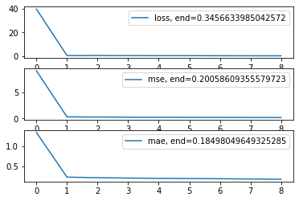

```python
BATCH_SIZE = 512
EPOCHS = 3
DEVICE = torch.device('cuda') if torch.cuda.is_available() else torch.device('cpu')

MAX_INPUT_LEN = 30

model14 = SalaryPredictorRecurrentBiGRU(max_len=MAX_INPUT_LEN).to(DEVICE)
criterion = nn.MSELoss(reduction='mean')
optimizer = torch.optim.Adam(model14.parameters(), lr=1e-3)

losses, mse, mae = [], [], []

for epoch in range(EPOCHS):
    print(f"epoch: {epoch}")
    for i, batch in tqdm.notebook.tqdm(enumerate(
            iterate_minibatches_fixed(
                    data_train,
                    batch_size=BATCH_SIZE,
                    max_len=MAX_INPUT_LEN,
                    device=DEVICE)),
                total=len(data_train) // BATCH_SIZE
        ):
        model14.train()
        pred = model14(batch)
        optimizer.zero_grad()
        loss = criterion(pred, batch[TARGET_COLUMN])
        loss.backward()
        optimizer.step()

        if i % 100 == 99:
            losses.append(loss.item())
            mse_item, mae_item = return_metrics_fixed(model14, data_val, name='val', batch_size=BATCH_SIZE, max_len=MAX_INPUT_LEN, device=DEVICE)
            mse.append(mse_item)
            mae.append(mae_item)

fig, ax = plt.subplots(nrows=3, ncols=1)

ax[0].plot(losses, label=f'loss, end={losses[-1]}')
ax[1].plot(mse, label=f'mse, end={mse[-1]}')
ax[2].plot(mae, label=f'mae, end={mae[-1]}')

for i in range(3):
    ax[i].legend(loc='upper right')

plt.show()
```

```python
models_and_metrics['experiment14'] = {}
models_and_metrics['experiment14']['losses'] = losses
models_and_metrics['experiment14']['mse'] = mse
models_and_metrics['experiment14']['mae'] = mae
```

## Сравнение моделей

```python
models = [model_base, model1, model2, model3, model4, model5, model6, model7,
          model8, model9, model10, model11,  # gensim
          model12, model13, model14,  # recurrent
          ]

for model in models[0:8]:
    mse_item, mae_item = return_metrics(model, data_holdout, name='val', batch_size=BATCH_SIZE, device=DEVICE)
    print(f'mse: {mse_item}, mae: {mae_item}')

print('Gensim models:')
for model in models[8:12]:
    mse_item, mae_item = return_metrics_gensim(model, data_holdout, name='val', batch_size=BATCH_SIZE, device=DEVICE)
    print(f'mse: {mse_item}, mae: {mae_item}')

print()
for model in models[12:]:
    mse_item, mae_item = return_metrics_fixed(model, data_holdout, name='val', batch_size=BATCH_SIZE, max_len=MAX_INPUT_LEN, device=DEVICE)
    print(f'mse: {mse_item}, mae: {mae_item}')
```

```
mse: 0.22346595128377278, mae: 0.19799272219340006
mse: 0.3332372029622396, mae: 0.24571491877237955
mse: 0.06107532978057861, mae: 0.08983024756113688
mse: 0.584878412882487, mae: 0.33177305857340494
mse: 0.10800210634867351, mae: 0.12365487416585287
mse: 0.421184508005778, mae: 0.25538385709126793
mse: 0.8242058436075846, mae: 0.3701987584431966
mse: 0.03759344816207886, mae: 0.06786204973856608
Gensim models:
mse: 0.24022164344787597, mae: 0.1928995927174886
mse: 0.34279073079427086, mae: 0.2311941146850586
mse: 0.20923145612080893, mae: 0.17890160878499348
mse: 0.07848374843597412, mae: 0.10131595929463705

mse: 0.2828015645345052, mae: 0.22179285685221353
mse: 0.09131089846293132, mae: 0.11490459442138672
mse: 0.19375128746032716, mae: 0.1809859275817871
```

Модель с GRU получилась лучшей среди рекурентных

## Эксперимент 15

GRU + среднее слово из описания

В ранней версии лабораторной был проведён эксперимент, где модель, берущая средние слова из Заголовка и Описания показывала лучшие результаты

```python
class SalaryPredictorMiddleWordAndGRU(nn.Module):
    def __init__(self, n_tokens=len(tokens), n_cat_features=len(categorical_vectorizer.vocabulary_), hid_size=4, max_len=30):
        super().__init__()
        self.embedder = nn.Embedding(n_tokens, hid_size)
        self.gru = nn.GRU(max_len, hid_size, 2)
        self.title_encoder = nn.Sequential(
            nn.GroupNorm(hid_size, hid_size),
            nn.Dropout(p=0.1),
            nn.ReLU(),
            nn.AdaptiveMaxPool1d(output_size=1)
        )
        self.description_encoder = nn.Sequential(
            nn.Conv1d(hid_size, hid_size, kernel_size=1),
            nn.Conv1d(hid_size, hid_size, kernel_size=1),
            nn.Conv1d(hid_size, hid_size, kernel_size=1),
            nn.GroupNorm(hid_size, hid_size),
            nn.Dropout(p=0.3),
            nn.ReLU(),
            nn.AdaptiveMaxPool1d(output_size=1)
        )
        self.categorical_encoder = nn.Sequential(
            nn.Linear(n_cat_features, hid_size * 2),
            nn.ReLU(),
            nn.Linear(hid_size * 2, hid_size * 2),
            nn.ReLU()
        )
        self.final_predictor = nn.Sequential(
            nn.Linear(hid_size * 4, hid_size),
            nn.ReLU(),
            nn.Linear(hid_size, 1)
        )


    def pick_middle_words(self, batch):
        middle_words = torch.Tensor([])
        for sentence in batch:
            normalized_sentence = sentence[sentence != PAD_IX]
            middle_word = normalized_sentence[len(normalized_sentence) // 2]
            middle_words = torch.cat([
                                      middle_words, torch.Tensor([middle_word])
                                    ])
        return middle_words.long().unsqueeze(1)


    def forward(self, batch):
        title_middle_words = self.pick_middle_words(batch['Title'])
        title_embeddings = self.embedder(title_middle_words).permute(0, 2, 1)
        title_features = self.title_encoder(title_embeddings).squeeze()

        description_embeddings = self.embedder(batch['FullDescription']).permute(0, 2, 1)
        description_features_gru, (h_n, c_n) = self.gru(description_embeddings)
        description_features = self.description_encoder(description_features_gru).squeeze()

        categorical_features = self.categorical_encoder(batch['Categorical'])

        features = torch.cat(
            [title_features, description_features, categorical_features], dim=1)

        return self.final_predictor(features).squeeze()
```

```
epoch: 0
```

```
epoch: 1
```

```
epoch: 2
```

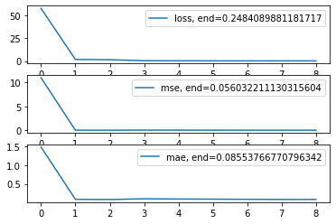

```python
BATCH_SIZE = 512
EPOCHS = 3
DEVICE = torch.device('cuda') if torch.cuda.is_available() else torch.device('cpu')

MAX_INPUT_LEN = 30

model15 = SalaryPredictorMiddleWordAndGRU(max_len=MAX_INPUT_LEN).to(DEVICE)
criterion = nn.MSELoss(reduction='mean')
optimizer = torch.optim.Adam(model15.parameters(), lr=1e-3)

losses, mse, mae = [], [], []

for epoch in range(EPOCHS):
    print(f"epoch: {epoch}")
    for i, batch in tqdm.notebook.tqdm(enumerate(
            iterate_minibatches_fixed(
                    data_train,
                    batch_size=BATCH_SIZE,
                    max_len=MAX_INPUT_LEN,
                    device=DEVICE)),
                total=len(data_train) // BATCH_SIZE
        ):
        model15.train()
        pred = model15(batch)
        optimizer.zero_grad()
        loss = criterion(pred, batch[TARGET_COLUMN])
        loss.backward()
        optimizer.step()

        if i % 100 == 99:
            losses.append(loss.item())
            mse_item, mae_item = return_metrics_fixed(model15, data_val, name='val', batch_size=BATCH_SIZE, max_len=MAX_INPUT_LEN, device=DEVICE)
            mse.append(mse_item)
            mae.append(mae_item)

fig, ax = plt.subplots(nrows=3, ncols=1)

ax[0].plot(losses, label=f'loss, end={losses[-1]}')
ax[1].plot(mse, label=f'mse, end={mse[-1]}')
ax[2].plot(mae, label=f'mae, end={mae[-1]}')

for i in range(3):
    ax[i].legend(loc='upper right')

plt.show()
```

```python
models_and_metrics['experiment15'] = {}
models_and_metrics['experiment15']['losses'] = losses
models_and_metrics['experiment15']['mse'] = mse
models_and_metrics['experiment15']['mae'] = mae
```

## Сравнение моделей

```python
models = [model_base, model1, model2, model3, model4, model5, model6, model7,
          model8, model9, model10, model11,  # gensim
          model12, model13, model14,  # recurrent
          model15
          ]

for model in models[0:8]:
    mse_item, mae_item = return_metrics(model, data_holdout, name='val', batch_size=BATCH_SIZE, device=DEVICE)
    print(f'mse: {mse_item}, mae: {mae_item}')

print('Gensim models:')
for model in models[8:12]:
    mse_item, mae_item = return_metrics_gensim(model, data_holdout, name='val', batch_size=BATCH_SIZE, device=DEVICE)
    print(f'mse: {mse_item}, mae: {mae_item}')

print()
for model in models[12:]:
    mse_item, mae_item = return_metrics_fixed(model, data_holdout, name='val', batch_size=BATCH_SIZE, max_len=30, device=DEVICE)
    print(f'mse: {mse_item}, mae: {mae_item}')
```

```
mse: 0.22346595128377278, mae: 0.19799272219340006
mse: 0.3332372029622396, mae: 0.24571491877237955
mse: 0.06107532978057861, mae: 0.08983024756113688
mse: 0.584878412882487, mae: 0.33177305857340494
mse: 0.10800210634867351, mae: 0.12365487416585287
mse: 0.421184508005778, mae: 0.25538385709126793
mse: 0.8242058436075846, mae: 0.3701987584431966
mse: 0.03759344816207886, mae: 0.06786204973856608
Gensim models:
mse: 0.24022164344787597, mae: 0.1928995927174886
mse: 0.34279073079427086, mae: 0.2311941146850586
mse: 0.20923145612080893, mae: 0.17890160878499348
mse: 0.07848374843597412, mae: 0.10131595929463705

mse: 0.2828015645345052, mae: 0.22179285685221353
mse: 0.09131089846293132, mae: 0.11490459442138672
mse: 0.19375128746032716, mae: 0.1809859275817871
mse: 0.052340137958526614, mae: 0.08202354907989502
```

Модель получилась одной из самых лучших

# Часть 5

## Эксперимент 16

Ансамбль деревьев решений

В качестве базовой модели будем использовать `model7`

```python
model7
```

```
SalaryPredictor7(
  (embedder): Embedding(34158, 4)
  (title_encoder): Sequential(
    (0): Conv1d(4, 4, kernel_size=(1,), stride=(1,))
    (1): Conv1d(4, 4, kernel_size=(1,), stride=(1,))
    (2): Conv1d(4, 4, kernel_size=(1,), stride=(1,))
    (3): GroupNorm(4, 4, eps=1e-05, affine=True)
    (4): Dropout(p=0.1, inplace=False)
    (5): ReLU()
  )
  (description_encoder): Sequential(
    (0): Conv1d(4, 4, kernel_size=(1,), stride=(1,))
    (1): Conv1d(4, 4, kernel_size=(1,), stride=(1,))
    (2): Conv1d(4, 4, kernel_size=(1,), stride=(1,))
    (3): GroupNorm(4, 4, eps=1e-05, affine=True)
    (4): Dropout(p=0.3, inplace=False)
    (5): ReLU()
  )
  (categorical_encoder): Sequential(
    (0): Linear(in_features=3768, out_features=8, bias=True)
    (1): ReLU()
    (2): Linear(in_features=8, out_features=8, bias=True)
    (3): ReLU()
  )
  (final_predictor): Sequential(
    (0): Linear(in_features=16, out_features=4, bias=True)
    (1): ReLU()
    (2): Linear(in_features=4, out_features=1, bias=True)
  )
)
```

```python
import copy

model7DecisionTree = copy.deepcopy(model7)
```

```python
mse, mae = return_metrics(model7DecisionTree, data_val, name='val', batch_size=BATCH_SIZE, device=DEVICE)
print(mse, mae)
```

```
0.038315963745117185 0.06827138120477849
```

```python
for param in model7DecisionTree.parameters():
    param.requires_grad = False
```

```python
# https://github.com/xuyxu/Soft-Decision-Tree

class SDT(nn.Module):
    def __init__(self, input_dim, output_dim, depth=5, lamda=1e-3, use_cuda=False):
        super(SDT, self).__init__()

        self.input_dim = input_dim
        self.output_dim = output_dim

        self.depth = depth
        self.lamda = lamda
        self.device = torch.device("cuda" if use_cuda else "cpu")

        self._validate_parameters()

        self.internal_node_num_ = 2 ** self.depth - 1
        self.leaf_node_num_ = 2 ** self.depth

        self.penalty_list = [
            self.lamda * (2 ** (-depth)) for depth in range(0, self.depth)
        ]

        self.inner_nodes = nn.Sequential(
            nn.Linear(self.input_dim + 1, self.internal_node_num_, bias=False),
            nn.Sigmoid(),
        )

        self.leaf_nodes = nn.Linear(self.leaf_node_num_, self.output_dim, bias=False)


    def forward(self, X, is_training_data=False):
        _mu, _penalty = self._forward(X)
        y_pred = self.leaf_nodes(_mu)
        if is_training_data:
            return y_pred, _penalty
        else:
            return y_pred


    def _forward(self, X):
        batch_size = X.size()[0]
        X = self._data_augment(X)

        path_prob = self.inner_nodes(X)
        path_prob = torch.unsqueeze(path_prob, dim=2)
        path_prob = torch.cat((path_prob, 1 - path_prob), dim=2)

        _mu = X.data.new(batch_size, 1, 1).fill_(1.0)
        _penalty = torch.tensor(0.0).to(self.device)

        begin_idx = 0
        end_idx = 1

        for layer_idx in range(0, self.depth):
            _path_prob = path_prob[:, begin_idx:end_idx, :]

            _penalty = _penalty + self._cal_penalty(layer_idx, _mu, _path_prob)
            _mu = _mu.view(batch_size, -1, 1).repeat(1, 1, 2)

            _mu = _mu * _path_prob

            begin_idx = end_idx
            end_idx = begin_idx + 2 ** (layer_idx + 1)

        mu = _mu.view(batch_size, self.leaf_node_num_)

        return mu, _penalty


    def _cal_penalty(self, layer_idx, _mu, _path_prob):
        penalty = torch.tensor(0.0).to(self.device)

        batch_size = _mu.size()[0]
        _mu = _mu.view(batch_size, 2 ** layer_idx)
        _path_prob = _path_prob.view(batch_size, 2 ** (layer_idx + 1))

        for node in range(0, 2 ** (layer_idx + 1)):
            alpha = torch.sum(
                _path_prob[:, node] * _mu[:, node // 2], dim=0
            ) / torch.sum(_mu[:, node // 2], dim=0)

            coeff = self.penalty_list[layer_idx]

            penalty -= 0.5 * coeff * (torch.log(alpha) + torch.log(1 - alpha))

        return penalty


    def _data_augment(self, X):
        batch_size = X.size()[0]
        X = X.view(batch_size, -1)
        bias = torch.ones(batch_size, 1).to(self.device)
        X = torch.cat((bias, X), 1)

        return X


    def _validate_parameters(self):

        if not self.depth > 0:
            msg = ("The tree depth should be strictly positive, but got {} instead.")
            raise ValueError(msg.format(self.depth))

        if not self.lamda >= 0:
            msg = ("The coefficient of the regularization term should not be negative, but got {} instead.")
            raise ValueError(msg.format(self.lamda))
```

```python
model7DecisionTree.final_predictor = nn.Sequential(
    SDT(16, 1)
)
```

```python
# вот так выглядит модель целиком

class SalaryPredictorDT(nn.Module):
    def __init__(self, n_tokens=len(tokens), n_cat_features=len(categorical_vectorizer.vocabulary_), hid_size=4):
        super().__init__()
        self.embedder = nn.Embedding(n_tokens, hid_size)
        self.title_encoder = nn.Sequential(
            nn.Conv1d(hid_size, hid_size, kernel_size=1),
            nn.Conv1d(hid_size, hid_size, kernel_size=1),
            nn.Conv1d(hid_size, hid_size, kernel_size=1),
            nn.GroupNorm(hid_size, hid_size),
            nn.Dropout(p=0.1),
            nn.ReLU(),
            nn.AdaptiveMaxPool1d(output_size=1)
        )
        self.description_encoder = nn.Sequential(
            nn.Conv1d(hid_size, hid_size, kernel_size=1),
            nn.Conv1d(hid_size, hid_size, kernel_size=1),
            nn.Conv1d(hid_size, hid_size, kernel_size=1),
            nn.GroupNorm(hid_size, hid_size),
            nn.Dropout(p=0.3),
            nn.ReLU(),
            nn.AdaptiveMaxPool1d(output_size=1)
        )
        self.categorical_encoder = nn.Sequential(
            nn.Linear(n_cat_features, hid_size * 2),
            nn.ReLU(),
            nn.Linear(hid_size * 2, hid_size * 2),
            nn.ReLU()
        )
        self.final_predictor = nn.Sequential(
           SDT(hid_size * 4, 1)
        )


    def mean(self, batch):
        with torch.no_grad():
            return batch.sum(axis=2) / (batch.sum(axis=1) > 0).sum(axis=1).view(-1,1).float()


    def forward(self, batch):
        title_embeddings = self.embedder(batch['Title']).permute(0, 2, 1)
        title_features = self.mean(self.title_encoder(title_embeddings))

        description_embeddings = self.embedder(batch['FullDescription']).permute(0, 2, 1)
        description_features = self.mean(self.description_encoder(description_embeddings))

        categorical_features = self.categorical_encoder(batch['Categorical'])

        features = torch.cat(
            [title_features, description_features, categorical_features], dim=1)

        return self.final_predictor(features).squeeze()
```

```
epoch: 0
```

```
epoch: 1
```

```
epoch: 2
```

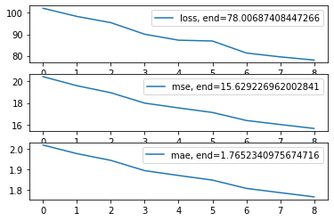

```python
BATCH_SIZE = 512
EPOCHS = 3
DEVICE = torch.device('cuda') if torch.cuda.is_available() else torch.device('cpu')

criterion = nn.MSELoss(reduction='mean')
optimizer = torch.optim.Adam(model7DecisionTree.parameters(), lr=1e-3)

losses, mse, mae = [], [], []

for epoch in range(EPOCHS):
    print(f"epoch: {epoch}")
    for i, batch in tqdm.notebook.tqdm(enumerate(
            iterate_minibatches(
                    data_train,
                    batch_size=BATCH_SIZE,
                    device=DEVICE)),
                total=len(data_train) // BATCH_SIZE
        ):
        model7DecisionTree.train()
        pred = model7DecisionTree(batch)
        optimizer.zero_grad()
        loss = criterion(pred, batch[TARGET_COLUMN])
        loss.backward()
        optimizer.step()

        if i % 100 == 99:
            losses.append(loss.item())
            mse_item, mae_item = return_metrics(model7DecisionTree, data_val, name='val', batch_size=BATCH_SIZE, device=DEVICE)
            mse.append(mse_item)
            mae.append(mae_item)

fig, ax = plt.subplots(nrows=3, ncols=1)

ax[0].plot(losses, label=f'loss, end={losses[-1]}')
ax[1].plot(mse, label=f'mse, end={mse[-1]}')
ax[2].plot(mae, label=f'mae, end={mae[-1]}')

for i in range(3):
    ax[i].legend(loc='upper right')

plt.show()
```

```python
models_and_metrics['experiment16'] = {}
models_and_metrics['experiment16']['losses'] = losses
models_and_metrics['experiment16']['mse'] = mse
models_and_metrics['experiment16']['mae'] = mae
```

## Сравнение моделей

```python
models = [model_base, model1, model2, model3, model4, model5, model6, model7,  # basic models
          model8, model9, model10, model11,  # gensim
          model12, model13, model14,  # recurrent
          model15,  # recurrent with middle word
          model7DecisionTree  # decision tree
          ]

print('Basic models:')
for model in models[0:8]:
    mse_item, mae_item = return_metrics(model, data_holdout, name='val', batch_size=BATCH_SIZE, device=DEVICE)
    print(f'mse: {mse_item}, mae: {mae_item}')

print('Gensim models:')
for model in models[8:12]:
    mse_item, mae_item = return_metrics_gensim(model, data_holdout, name='val', batch_size=BATCH_SIZE, device=DEVICE)
    print(f'mse: {mse_item}, mae: {mae_item}')

print('Recurrent:')
for model in models[12:16]:
    mse_item, mae_item = return_metrics_fixed(model, data_holdout, name='val', batch_size=BATCH_SIZE, max_len=30, device=DEVICE)
    print(f'mse: {mse_item}, mae: {mae_item}')

print('Decision tree:')
for model in models[16:]:
    mse_item, mae_item = return_metrics(model, data_holdout, name='val', batch_size=BATCH_SIZE, device=DEVICE)
    print(f'mse: {mse_item}, mae: {mae_item}')
```

```
Basic models:
mse: 0.22346595128377278, mae: 0.19799272219340006
mse: 0.3332372029622396, mae: 0.24571491877237955
mse: 0.06107532978057861, mae: 0.08983024756113688
mse: 0.584878412882487, mae: 0.33177305857340494
mse: 0.10800210634867351, mae: 0.12365487416585287
mse: 0.421184508005778, mae: 0.25538385709126793
mse: 0.8242058436075846, mae: 0.3701987584431966
mse: 0.03759344816207886, mae: 0.06786204973856608
Gensim models:
mse: 0.24022164344787597, mae: 0.1928995927174886
mse: 0.34279073079427086, mae: 0.2311941146850586
mse: 0.20923145612080893, mae: 0.17890160878499348
mse: 0.07848374843597412, mae: 0.10131595929463705
Recurrent:
mse: 0.2828015645345052, mae: 0.22179285685221353
mse: 0.09131089846293132, mae: 0.11490459442138672
mse: 0.19375128746032716, mae: 0.1809859275817871
mse: 0.052340137958526614, mae: 0.08202354907989502
Decision tree:
mse: 15.32904052734375, mae: 1.748166275024414
```

Модель получилась самой худшей. Попробуем обучить модель "с нуля"

## Эксперимент 17

Decision Tree с нуля

```
epoch: 0
```

```
epoch: 1
```

```
epoch: 2
```

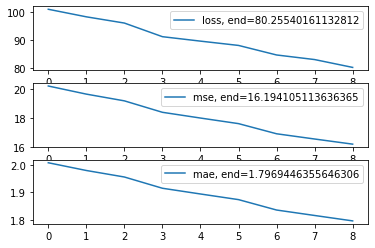

```python
BATCH_SIZE = 512
EPOCHS = 3
DEVICE = torch.device('cuda') if torch.cuda.is_available() else torch.device('cpu')

model17 = SalaryPredictorDT()
criterion = nn.MSELoss(reduction='mean')
optimizer = torch.optim.Adam(model17.parameters(), lr=1e-3)

losses, mse, mae = [], [], []

for epoch in range(EPOCHS):
    print(f"epoch: {epoch}")
    for i, batch in tqdm.notebook.tqdm(enumerate(
            iterate_minibatches(
                    data_train,
                    batch_size=BATCH_SIZE,
                    device=DEVICE)),
                total=len(data_train) // BATCH_SIZE
        ):
        model17.train()
        pred = model17(batch)
        optimizer.zero_grad()
        loss = criterion(pred, batch[TARGET_COLUMN])
        loss.backward()
        optimizer.step()

        if i % 100 == 99:
            losses.append(loss.item())
            mse_item, mae_item = return_metrics(model17, data_val, name='val', batch_size=BATCH_SIZE, device=DEVICE)
            mse.append(mse_item)
            mae.append(mae_item)

fig, ax = plt.subplots(nrows=3, ncols=1)

ax[0].plot(losses, label=f'loss, end={losses[-1]}')
ax[1].plot(mse, label=f'mse, end={mse[-1]}')
ax[2].plot(mae, label=f'mae, end={mae[-1]}')

for i in range(3):
    ax[i].legend(loc='upper right')

plt.show()
```

```python
models_and_metrics['experiment17'] = {}
models_and_metrics['experiment17']['losses'] = losses
models_and_metrics['experiment17']['mse'] = mse
models_and_metrics['experiment17']['mae'] = mae
```

## Сравнение моделей

```python
models = [model_base, model1, model2, model3, model4, model5, model6, model7,  # basic models
          model8, model9, model10, model11,  # gensim
          model12, model13, model14,  # recurrent
          model15,  # recurrent with middle word
          model7DecisionTree, model17  # decision tree
          ]

print('Basic models:')
for model in models[0:8]:
    mse_item, mae_item = return_metrics(model, data_holdout, name='val', batch_size=BATCH_SIZE, device=DEVICE)
    print(f'mse: {mse_item}, mae: {mae_item}')

print('Gensim models:')
for model in models[8:12]:
    mse_item, mae_item = return_metrics_gensim(model, data_holdout, name='val', batch_size=BATCH_SIZE, device=DEVICE)
    print(f'mse: {mse_item}, mae: {mae_item}')

print('Recurrent:')
for model in models[12:16]:
    mse_item, mae_item = return_metrics_fixed(model, data_holdout, name='val', batch_size=BATCH_SIZE, max_len=30, device=DEVICE)
    print(f'mse: {mse_item}, mae: {mae_item}')

print('Decision tree:')
for model in models[16:]:
    mse_item, mae_item = return_metrics(model, data_holdout, name='val', batch_size=BATCH_SIZE, device=DEVICE)
    print(f'mse: {mse_item}, mae: {mae_item}')
```

```
Basic models:
mse: 0.22346595128377278, mae: 0.19799272219340006
mse: 0.3332372029622396, mae: 0.24571491877237955
mse: 0.06107532978057861, mae: 0.08983024756113688
mse: 0.584878412882487, mae: 0.33177305857340494
mse: 0.10800210634867351, mae: 0.12365487416585287
mse: 0.421184508005778, mae: 0.25538385709126793
mse: 0.8242058436075846, mae: 0.3701987584431966
mse: 0.03759344816207886, mae: 0.06786204973856608
Gensim models:
mse: 0.24022164344787597, mae: 0.1928995927174886
mse: 0.34279073079427086, mae: 0.2311941146850586
mse: 0.20923145612080893, mae: 0.17890160878499348
mse: 0.07848374843597412, mae: 0.10131595929463705
Recurrent:
mse: 0.2828015645345052, mae: 0.22179285685221353
mse: 0.09131089846293132, mae: 0.11490459442138672
mse: 0.19375128746032716, mae: 0.1809859275817871
mse: 0.052340137958526614, mae: 0.08202354907989502
Decision tree:
mse: 15.32904052734375, mae: 1.748166275024414
mse: 15.90254414876302, mae: 1.7806654612223307
```

Модель всё равно плохая

# Часть 6

## Эксперимент 18

SoftMaxPooling вместо AdaptiveMaxPooling

$$ out_{i, t} = \sum_t {h_{i,t} \cdot {{e ^ {h_{i, t}}} \over \sum_\tau e ^ {h_{j, \tau}} } }$$

```python
inp = torch.rand(2, 2)
inp
```

```
tensor([[0.4794, 0.1054],
        [0.3421, 0.7177]])
```

```python
def softmax(x):
    exps = torch.exp(x)  # e^(h_i, t)
    sum_exps = torch.sum(exps, dim=1).unsqueeze(-1)  # sum_T e^(h_j, T)
    ones = torch.ones(sum_exps.shape)
    ones_by_sum_exps = ones.div(sum_exps)  # 1 / (...)
    numer = torch.mul(x, exps)  # h_i, t * e^(h_i, t)
    return torch.Tensor(numer @ ones_by_sum_exps).squeeze()
```

```python
softmax(inp)
```

```
tensor([0.3179, 0.6021])
```

```python
class SoftMaxPooling(nn.Module):
    def __init__(self):
        super().__init__()


    def forward(self, x: torch.Tensor):
        exps = torch.exp(x)  # e^(h_i, t)
        sum_exps = torch.sum(exps, dim=1).unsqueeze(-1)  # sum_T e^(h_j, T)
        ones = torch.ones(sum_exps.shape)
        ones_by_sum_exps = ones.div(sum_exps)  # 1 / (...)
        numer = torch.mul(x, exps)  # h_i, t * e^(h_i, t)
        return torch.Tensor(numer @ ones_by_sum_exps).squeeze()
```

```python
class SalaryPredictorSoftMax(nn.Module):
    def __init__(self, n_tokens=len(tokens), n_cat_features=len(categorical_vectorizer.vocabulary_), hid_size=4):
        super().__init__()
        self.embedder = nn.Embedding(n_tokens, hid_size)
        self.title_encoder = nn.Sequential(
            nn.Conv1d(hid_size, hid_size, kernel_size=1),
            nn.Conv1d(hid_size, hid_size, kernel_size=1),
            nn.Conv1d(hid_size, hid_size, kernel_size=1),
            nn.GroupNorm(hid_size, hid_size),
            nn.Dropout(p=0.1),
            SoftMaxPooling()
        )
        self.description_encoder = nn.Sequential(
            nn.Conv1d(hid_size, hid_size, kernel_size=1),
            nn.Conv1d(hid_size, hid_size, kernel_size=1),
            nn.Conv1d(hid_size, hid_size, kernel_size=1),
            nn.GroupNorm(hid_size, hid_size),
            nn.Dropout(p=0.3),
            SoftMaxPooling()
        )
        self.categorical_encoder = nn.Sequential(
            nn.Linear(n_cat_features, hid_size * 2),
            nn.ReLU(),
            nn.Linear(hid_size * 2, hid_size * 2),
            nn.ReLU()
        )
        self.final_predictor = nn.Sequential(
            nn.Linear(hid_size * 4, hid_size),
            nn.ReLU(),
            nn.Linear(hid_size, 1)
        )


    def forward(self, batch):
        title_embeddings = self.embedder(batch['Title']).permute(0, 2, 1)
        title_features = self.title_encoder(title_embeddings).squeeze()

        description_embeddings = self.embedder(batch['FullDescription']).permute(0, 2, 1)
        description_features = self.description_encoder(description_embeddings).squeeze()

        categorical_features = self.categorical_encoder(batch['Categorical'])

        features = torch.cat(
            [title_features, description_features, categorical_features], dim=1)

        return self.final_predictor(features).squeeze()
```

```
epoch: 0
```

```
epoch: 1
```

```
epoch: 2
```

```
epoch: 3
```

```
epoch: 4
```

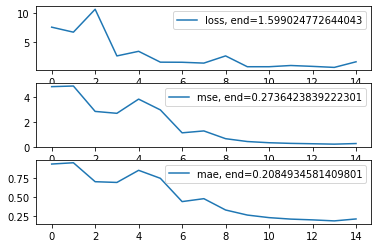

```python
BATCH_SIZE = 512
EPOCHS = 5
DEVICE = torch.device('cuda') if torch.cuda.is_available() else torch.device('cpu')

model18 = SalaryPredictorSoftMax()
criterion = nn.MSELoss(reduction='mean')
optimizer = torch.optim.Adam(model18.parameters(), lr=1e-3)

losses, mse, mae = [], [], []

for epoch in range(EPOCHS):
    print(f"epoch: {epoch}")
    for i, batch in tqdm.notebook.tqdm(enumerate(
            iterate_minibatches(
                    data_train,
                    batch_size=BATCH_SIZE,
                    device=DEVICE)),
                total=len(data_train) // BATCH_SIZE
        ):
        model18.train()
        pred = model18(batch)
        optimizer.zero_grad()
        loss = criterion(pred, batch[TARGET_COLUMN])
        loss.backward()
        optimizer.step()

        if i % 100 == 99:
            losses.append(loss.item())
            mse_item, mae_item = return_metrics(model18, data_val, name='val', batch_size=BATCH_SIZE, device=DEVICE)
            mse.append(mse_item)
            mae.append(mae_item)

fig, ax = plt.subplots(nrows=3, ncols=1)

ax[0].plot(losses, label=f'loss, end={losses[-1]}')
ax[1].plot(mse, label=f'mse, end={mse[-1]}')
ax[2].plot(mae, label=f'mae, end={mae[-1]}')

for i in range(3):
    ax[i].legend(loc='upper right')

plt.show()
```

Модели нужно сильно больше времени, чтобы достаточно обучиться

```python
models_and_metrics['experiment18'] = {}
models_and_metrics['experiment18']['losses'] = losses
models_and_metrics['experiment18']['mse'] = mse
models_and_metrics['experiment18']['mae'] = mae
```

## Сравнение моделей

```python
models = [model_base, model1, model2, model3, model4, model5, model6, model7,  # basic models
          model8, model9, model10, model11,  # gensim
          model12, model13, model14,  # recurrent
          model15,  # recurrent with middle word
          model7DecisionTree, model17,  # decision tree
          model18
          ]

print('Basic models:')
for model in models[0:8]:
    mse_item, mae_item = return_metrics(model, data_holdout, name='val', batch_size=BATCH_SIZE, device=DEVICE)
    print(f'mse: {mse_item}, mae: {mae_item}')

print('Gensim models:')
for model in models[8:12]:
    mse_item, mae_item = return_metrics_gensim(model, data_holdout, name='val', batch_size=BATCH_SIZE, device=DEVICE)
    print(f'mse: {mse_item}, mae: {mae_item}')

print('Recurrent:')
for model in models[12:16]:
    mse_item, mae_item = return_metrics_fixed(model, data_holdout, name='val', batch_size=BATCH_SIZE, max_len=30, device=DEVICE)
    print(f'mse: {mse_item}, mae: {mae_item}')

print('Decision tree:')
for model in models[16:18]:
    mse_item, mae_item = return_metrics(model, data_holdout, name='val', batch_size=BATCH_SIZE, device=DEVICE)
    print(f'mse: {mse_item}, mae: {mae_item}')

print('SoftMax:')
for model in models[18:]:
    mse_item, mae_item = return_metrics(model, data_holdout, name='val', batch_size=BATCH_SIZE, device=DEVICE)
    print(f'mse: {mse_item}, mae: {mae_item}')
```

```
Basic models:
mse: 0.22346595128377278, mae: 0.19799272219340006
mse: 0.3332372029622396, mae: 0.24571491877237955
mse: 0.06107532978057861, mae: 0.08983024756113688
mse: 0.584878412882487, mae: 0.33177305857340494
mse: 0.10800210634867351, mae: 0.12365487416585287
mse: 0.421184508005778, mae: 0.25538385709126793
mse: 0.8242058436075846, mae: 0.3701987584431966
mse: 0.03759344816207886, mae: 0.06786204973856608
Gensim models:
mse: 0.24022164344787597, mae: 0.1928995927174886
mse: 0.34279073079427086, mae: 0.2311941146850586
mse: 0.20923145612080893, mae: 0.17890160878499348
mse: 0.07848374843597412, mae: 0.10131595929463705
Recurrent:
mse: 0.2828015645345052, mae: 0.22179285685221353
mse: 0.09131089846293132, mae: 0.11490459442138672
mse: 0.19375128746032716, mae: 0.1809859275817871
mse: 0.052340137958526614, mae: 0.08202354907989502
Decision tree:
mse: 15.32904052734375, mae: 1.748166275024414
mse: 15.90254414876302, mae: 1.7806654612223307
SoftMax:
mse: 0.11911416053771973, mae: 0.12757531801859537
```

Модель получилась вполне достойной